# The content and structure of reputation domains across human societies: a view from the evolutionary social sciences

Zachary H. Garfield<sup>1ª</sup>, Ryan Schacht<sup>2</sup>, Emily R. Post<sup>3</sup>, Dominique Ingram<sup>3</sup>, Andrea Uehling<sup>3</sup>, and Shane J. Macfarlan<sup>3ª</sup>

07 May 2021

<sup>1</sup> Institute for Advanced Study in Toulouse, Université de Toulouse 1 Capitole, Toulouse, France; <sup>2</sup> Department of Anthropology, East Carolina University, Greenville, NC, USA; <sup>3</sup> Department of Anthropology, University of Utah, Salt Lake City, UT, USA

ªCorresponding authors

zachary.garfield@iast.fr  
shane.macfarlan@anthro.utah.edu

**Keywords:** Reputation, Prosociality, Cooperation, Human Uniqueness, Cross-Cultural Analysis

[figure not shown]

OSF DOI: 10.31219/osf.io/mk4wq

## Abstract

Reputations are an essential feature of human sociality and the evolution of cooperation and group living. Much scholarship has focused on reputations, yet typically on a narrow range of domains (e.g., prosociality, aggressiveness), usually in isolation. Humans can develop reputations, however, from any collective information. We conducted exploratory analyses on the content, distribution, and structure of reputation domain diversity across cultures, using the Human Relations Area Files ethnographic database. After coding ethnographic texts on reputations from 153 cultures, we used hierarchical modelling, cluster analysis, and text analysis to provide an empirical view of reputation domains across societies. Findings suggest: 1) reputational domains vary cross-culturally, yet reputations for cultural conformity, prosociality, social status, and neural capital are widespread; 2) reputation domains are more variable for males than females; and 3) particular reputation domains are interrelated, demonstrating a structure consistent with dimensions of human uniqueness. We label these features: *Cultural group unity*, *Dominance*, *Neural capital*, *Sexuality*, *Social and material success*, and *Supernatural healing*. We highlight the need for future research on the evolution of cooperation and human sociality to consider a wider range of reputation domains, as well as their social, ecological, and gender-specific variability.

## Introduction

Reputations are essential for human sociality. Whether used to punish norm violators in small communities or orient behaviour in anonymous online markets, reputations matter [1]. Reputations represent collective beliefs and evaluations a community forms about an individual’s behavioural or emotional tendencies [2,3]. They function as currencies in a social marketplace with individuals signalling qualities relative to peers [4,5]. Such signals can reduce transaction costs in the formation, maintenance, and termination of relationships by providing information about others without direct experience [6]. Because reputations can facilitate prosocial behaviour and punish deviancy, they provide some cognitive scaffolding supporting human sociality, including, the formation of status hierarchies [7,8], social institutions [9], and prosociality [10,11]. Many species rely on reputation-information exchange [12]. Among humans, however, language and gossip creates a selective environment whereby reputations have significant social consequences [13–15].

Individual reputations can develop for any domain in which collective information exists on people’s behavioural or emotional tendencies [16]. As new formats of social interaction emerge, the human behavioural repertoire becomes unbounded [17], suggesting an unlimited number of potential reputation domains. Nevertheless, evolutionary scholars have typically focused on a narrow range of reputation domains, such as prosociality [14,18–21], competency [3,22,23], aggressiveness [24–26], and sexuality [27,28]. This research has produced valuable insights on the influence of particular reputation domains on facets of social interaction [4], gendered relationships [28], and the evolution of social systems [29].

Research on reputations has remained agnostic, however, about the scope of reputation domains within societies, their frequency across cultures, and potential gender biases [30]. Furthermore, research has often occurred in a piece-meal fashion focusing on a single domain, obfuscating the degree to which domains interact and shape behavioural responses as a suite of integrated parts (however, see [3]). Current scholarship lacks a clear understanding of the content, structure, and diversity of reputation domains across societies.

We seek to build a foundation for comparative approaches to reputation domain diversity through exploratory analyses of the ethnographic record. We first derive a list of *a priori* reputation domains (discussed in the Supplementary Information [SI]). We then assess the cross-cultural frequency of evidence for reputation domains and how evidence for gender-specific reputations varies. Lastly, we identify features of reputation domain co-occurrence and the semantic content of ethnography describing reputations. The following aims guide our study:

- Aim 1: To assess the distribution of ethnographic evidence for reputation domains.
- Aim 2: To identify if reputation domains exhibit systematic gender-biases and if these domains vary within gender.
- Aim 3: To identify the structure and interrelationships of reputation domains.
- Aim 4: To reveal the semantic content of reputation domains in the ethnographic record.

Existing work provides strong rationale for both putative universality in human reputation domains, as well as variation by social, ecological, or gender-specific pressures. Leveraging the ethnographic record in a systematic framework, despite limitations and potential biases (see Materials and Methods, Discussion), is a first step in uncovering patterns across human societies.

## Materials and Methods

### Ethnographic sample and coding

To accomplish our aims we relied on the electronic Human Relations Area Files (eHRAF) – an online database of primary ethnographic documents. It should be noted, the ethnographic record is male-biased given the majority of ethnographers have been men and their writings and observations have generally prioritized (deliberately or not) the behaviour and social lives of men [31,32].

The eHRAF includes thousands of documents from over 300 cultures indexed by subject at the paragraph-level [33]. Users can generate a sample of ethnographic texts (i.e., paragraphs) using Boolean searches of subject codes and/or key words. Our dataset was compiled using a keyword *and* eHRAF’s indexing system, the Outline of Cultural Materials (OCM), which associates each paragraph with any of over 700 subject codes covering a range of topics relevant for the human sciences. We conducted an “Advanced Search” of the keyword “reputation” with any of the OCM subjects: *Social Personality*, *Personality Traits*, or *Status, Role, and Prestige*. This search aimed to strike a balance between retrieving a generalizable yet manageable sample of the ethnography of reputations. A limitation is that our search may have omitted particular domains of reputations. See the SI for additional details.

We read the resulting 1383 paragraphs for content, excluding those referencing reputations for groups, non-human entities, or ethnographers. We applied these inclusion criteria because our goal is to understand individual reputations within a particular culture. We then aggregated paragraphs from the same document. This resulted in a dataset containing 319 documents from 153 diverse cultures with broad geographic coverage (see Figure S5 and Table S1). These documents had a mean word count of 140 (SD of 160 and range of 14 to 1957). We refer to this as our *Document dataset*, which is publicly available in the *Reputation Diversity Database* R package [34], including bibliographic information, culture sample, and all data.

We derived, *a priori*, 20 reputation domains from the scientific literature on human sociality. These include: *Aggressiveness*, *Bravery*, *Coercive ability*, *Cooperation*, *Cultural conformity*, *Honesty*, *Industriousness*, *Material capital*, *Medicine*, *Neural capital*, *Oration*, *Parental care*, *Prosociality*, *Sexual fidelity*, *Social capital*, *Social status*, *Sociosexuality*, *Somatic capital*, *Supernatural ability*, and *Teaching* (see the SI for discussion on operationalization and inclusion). Each domain is operationalized as having both a positive and negative valence. For example, evidence for the reputation domain *Neural capital* – which includes reputations for generalized or specialized intelligence, special knowledge, or cognitive abilities – could be based on evidence that a given society values expertise, as well as evidence indicating that a group actively detests mental ineptitude (or *vice versa*). Using these operationalized reputation domains, we coded the 319 documents in the *Document dataset* for supporting evidence across the 20 reputation domains. Authors decomposed into groups of two were allocated a subset of documents (approximately 106 per pair) to read and code, indicating supporting evidence for each domain and whether the evidence was gendered: male-specific, female-specific, or gender neutral. We did not compute inter-coder reliability measures given coders varied in experience reading and coding ethnographic texts and common inter-rater reliability statistics can produce misleadingly low reliability metrics despite relatively high levels of simple agreement for sparse matrices, such as our data [35,36]. Author-pairs compared coded data to resolve disagreements. For divergent codings the text and operational definitions were reviewed and consensus reached on the appropriate coding. The aggregated resolved codings constitute our data. See the SI for example text and coding.

### Data analysis

The current study is primarily exploratory. We rely on descriptive and exploratory statistical approaches to accomplish our aims. We assess the cross-cultural support for each reputation domain by estimating the proportion of documents providing supporting evidence, including across our gender coding (represented as a percentage estimate). Because our *Document dataset* is a sample of the ethnographic record and because multiple documents often described the same culture, we incorporated uncertainty accounting for this non-independence and hierarchical structure with generalized linear mixed effects regression models (GLMM) with random effects for culture using the lme4 package [37]. Some analyses are agnostic to gender-specific codings and any coding (female-specific, male-specific, or gender neutral) counts as supporting evidence, while others account for gender-specific codings.

To estimate the frequency of supporting evidence for each reputation domain, we fit intercept-only GLMMs with random intercepts for culture, with each binary-coded reputation domain as outcomes, for all coded data (i.e., evidence for each reputation domain independent of gender-specific codings). We also fit identical models for female-specific and male-specific evidence. These GLMMs estimate the proportion of documents providing evidence for the reputation domains (i.e., the fixed effect with 95% CI) adjusting for the non-independence of documents from the same culture (Aims 1 and 2). We also compute the percentage of cultures with at least one document providing supporting evidence for each reputation domain (independent of gender coding), with 95% CI estimated using a cluster bootstrap and 1000 samples with replacement (Aim 1).

Using all data, where each row represents the gender-specific evidence for each document, we assess gender-biased evidence for each reputation domain by comparing (via information criterion model selection) an intercept-only GLMM (with random intercepts for documents nested within culture and for culture language family) to similar models which include a gender-term covariate (Aim 2).

We rely on hierarchical cluster analysis to identify structure (i.e., features) among reputation domains (Aim 3). We then use text-analytic methods and a document-term matrix of our corpus of ethnography with penalized regression to identify semantic content predictive of evidence for reputation features (Aim 4).

We also investigated sources of bias in our coded data due to features of the ethnographic record. We used the presence of a female coauthor, document publication year, and total pages of ethnography per culture in the eHRAF as predictors of our reputation domains (accounting for the hierarchical document-culture structure and culture language family).

All analyses were conducted with R version 4.0.2 (2020-06-22).

## Results

Evidence for reputation domains varied across subsistence types with horticulturalists and agriculturalists overrepresented relative to pastoralists and hunter-gatherers (Table S1). Evidence was also male-biased. Of the 1252 counts of supporting evidence across domains, 695 (56%) were coded as male-specific, 418 (33%) were coded as gender neutral, and 139 (11%) were coded as female-specific (Table S2).

Bias assessment analyses did not identify strong evidence of bias due to our meta-ethnographic measures. Consequently, we did not incorporate such measures in analyses. See the SI for results.

### Evidence for reputation domains

For all 20 reputation domains, we report the percentage of cultures that provided at least one count of supporting evidence, independent of gender coding. At the culture-level, the most strongly supported domains, documented in over 50% of cultures included *Cultural conformity*, *Neural capital*, *Prosociality*, and *Social status* (Figure 1A).

We report the proportion of documents that provided supporting evidence including for gender-specific evidence (Figure 1B). At the document-level, the most strongly supported domains, represented in over 30% of documents, included *Cultural conformity*, *Prosociality*, *Social status*, *Neural capital*, and *Industriousness.* Evidence for these reputation domains was strongly male-biased, in particular *Social status* and *Neural capital* which were the most supported male-specific domains. The most strongly supported female-specific reputation domains (although male-biased overall) were *Cultural conformity* and *Industriousness*. The between-domain variation among female-specific evidence was minimal compared to the male-specific evidence which was more variable. We emphasize the relatively low levels of female-specific evidence could be a feature of systemic male-bias in the ethnographic record, more so than gendered patterns of social or cultural diversity (see Discussion).

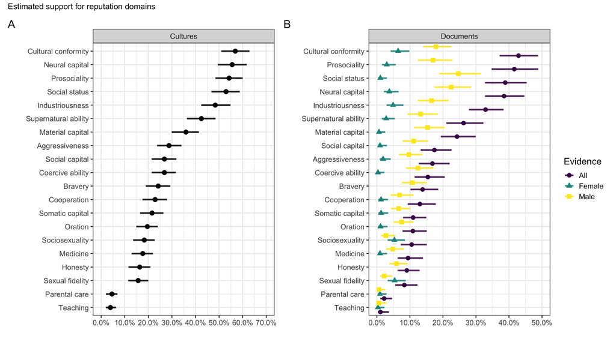

Figure 1: Evidence for reputation domains. A: Percentage of cultures providing at least one supporting document (95% CI estimated using a cluster bootstrap). B: Percent of documents providing supporting evidence (95% CI computed with intercept-only mixed effects models). Purple circles: Estimates from all data independent of gender coding. Green triangles: Estimates from *female-specific* evidence. Yellow squares: Estimates from *male-specific* evidence.

To assess gender-biases in the supporting evidence for reputation domains, we fit two binomial GLMMs of each reputation domain using the entire data set, where each row represents the gender-specific evidence for each document (i.e., female-specific, male-specific, gender neutral; three rows per document). The first model was an intercept-only GLMM with the binary coded reputation domains as outcomes and random intercepts for document nested within culture (to account for the repeated measures of evidence type per document and multiple documents per culture) and a random intercept for culture language family (to partially account for shared ancestry). These intercept-only models were compared to similar models which included gender-evidence type as a covariate. We compared the intercept-only models to their respective gender-term models using Akaike Information Criterion (AIC) [38]. Gender was deemed to be a predictor of reputation domain evidence when $AIC \Delta <-2$ [39]. Results are reported in Table S3 and support patterns in Figure 1B. Evidence for all domains was male-biased with the following exceptions: *Sociosexuality*, *Parental care*, and *Teaching* did not demonstrate gender biases and *Sexual fidelity* was female-biased. Two reputation domains (*Bravery* and *Honesty*) did not produce female-specific evidence and were not included.

### Structural features of reputation domains

Evidence for different reputation domains may co-occur within documents, putatively suggesting domain interrelatedness and structure. To identify features (i.e., clusters) of domains we used agglomerative hierarchical cluster analysis. See the SI for details.

Figure 2 displays a dendrogram from cluster analysis of the 20 reputation domains, which includes two estimates of significance for how strongly each cluster is supported by the data. We rely on the AU (approximately unbiased) *p* values (represented in red at each cluster’s “edge”), which are computed by multiscale bootstrap resampling and represented as percentages (clusters with AU values $\gt95$ are strongly supported; top-level clusters are automatically outlined by red rectangles). This revealed five strongly supported clusters we *post hoc* identify as *Sexuality*, *Dominance*, *Supernatural healing*, *Social and material success*, and *Cultural group unity*. We used these clusters to compute new variables, henceforth reputation domain *features*. Although the cluster capturing *Neural capital* and *Oration* was only moderately supported (AU $= 76$), given *Neural capital* was among the most frequent domains and oratory abilities are a type of neural capital we computed a *Neural capital* feature from this cluster. For each document, these six reputation domain features are coded as $1$, when any of the associated domains provided supporting evidence.

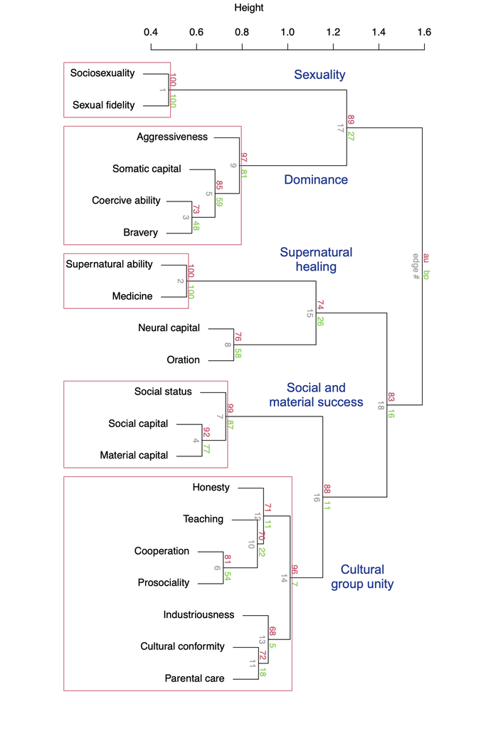

Figure 2: Cluster analysis of reputation domains. Distances were $1-cor$. Ward agglomeration method. AU p-values (red) computed with 10,000 bootstrap samples using the pvclust package [40]. Edge number in grey.

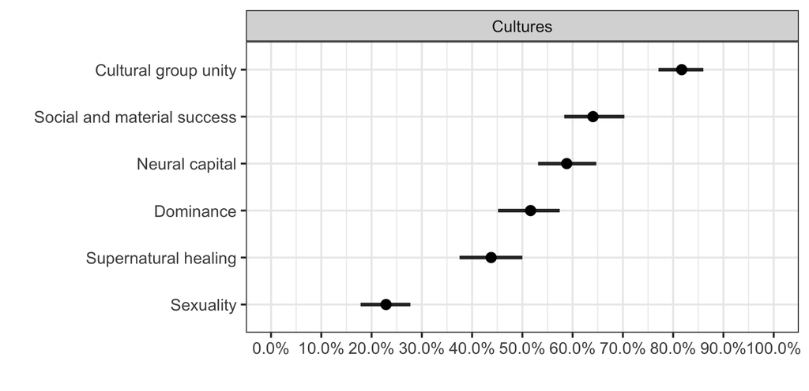

Figure 3: Percentage of cultures providing evidence for reputation features (95% CI estimated via cluster bootstrap).

### The ethnography of reputation domains

We used text analysis to explore the ethnography of reputation domains in reference to our six features. We created a document-term matrix (DTM) of all “informative” words in our corpus of texts which captures the frequency of each unique term within each document. We fit an elastic net logistic regression model (with the lasso penalty, $\alpha = 1$) of each of the six features as a function of the frequencies of all 8770 unique words (using the glmnet package [41]). Words that were strong positive predictors epitomized the semantic content of documents which provided evidence for that feature. Figure 4 displays non-zero coefficients from elastic net lasso regression models of each reputation domain feature.

Evidence for the *Cultural group unity* feature was positively predicted by terms related to social relationships and community (e.g., *family*, *person*, *wife*) and negatively predicted by terms related to the supernatural (e.g., *spirit*, *shaman*). Evidence for the *Social and material success* feature was positively predicted by *wealth*, *prestige*, and terms for leadership and status. Evidence for the *Neural capital* feature was positively predicted by *skill*, *leader*, and *village*. Evidence for the *Dominance* feature was positively predicted by *war*, *strong*, *kill*, and *physical* implicating reputations for dominance with conflict, physical formidability, and aggression. Negative predictors of the *Dominance* feature included *status* and *wealth*, suggesting a distinction between dominance and prestige. Evidence for the *Supernatural healing* feature was positively predicted by the terms, *shaman*, *cure*, *power*, and *medicine*; *woman* was a weak negative predictor. Evidence for the *Sexuality* feature was predicted by *girl*, *woman*, and *sexual*.

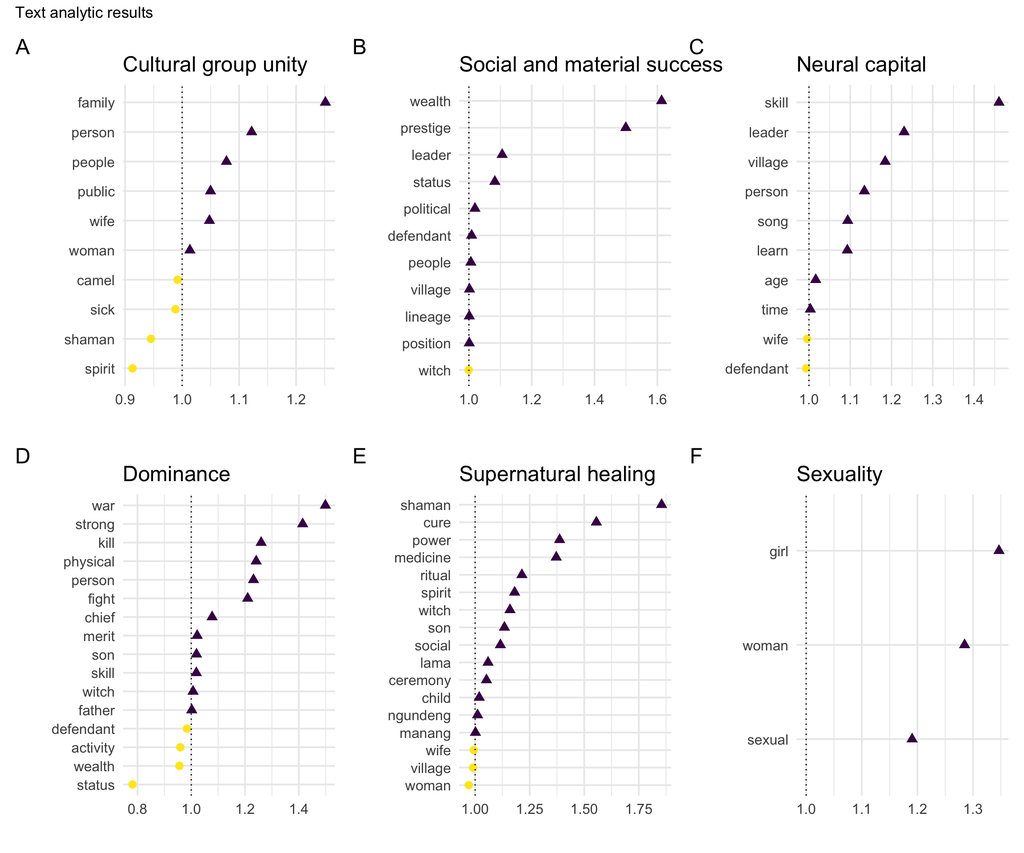

Figure 4: Non-zero coefficients from text analysis elastic net regression models of evidence for reputation features. Coefficients indicate the words in each document which best predicted evidence for the feature. Positive coefficients as purple triangles. Negative coefficients as yellow circles.

## Discussion

The content, structure, and diversity of reputation domains across societies are understudied from a holistic perspective. The current study was motivated by a lack of cross-cultural research, despite widespread theorizing in biology, psychology and anthropology regarding the role of reputations for sociality and evolutionary dynamics. Using the eHRAF database we extracted ethnographic accounts of individual-level reputation domains. Results suggest: 1) there is considerable cross-cultural variability in evidence for reputation domains – some domains are common in the ethnographic record (e.g., cultural conformity, prosociality) while others are relatively rare (e.g., teaching, honesty); 2) evidence for most reputations are male-biased with male-specific reputation domains more variable than female-specific domains; and 3) reputation domains cluster within six features: cultural group unity, dominance, neural capital, sexuality, social and material success, and supernatural healing. Below we interpret results from an evolutionary social science perspective.

### Diversity in reputation domains

Most reputation domains (16 of 20) were documented in less than half of sampled cultures (Figures 1A and 3). Despite variability, some were more common than others, including reputations for cultural conformity, prosociality, social status, neural capital, and industriousness. These results are notable because of what is missing: “cooperation.” Evolutionary-oriented scholars have implicated cooperative reputations for explaining human ultrasociality [5,13,14], yet reputations for “cooperativeness” were documented in only 23% of cultures. Reputations indirectly related to cooperation (e.g., conformity, honesty, social relationships, and industriousness), however, were common across societies. Reputations for cooperation were also captured by the most common feature: cultural group unity (Figure 3). The limited evidence of reputations for cooperativeness could be due in part to the nature of the ethnographic record (see Limitations) or a product of our operational definition. We follow developmental and neuro-psychologists [23,42,43] by differentiating cooperation – defined as the likelihood an individual intentionally assists another in order to achieve a joint goal – from prosociality – defined as the likelihood one will invest in group welfare or act in group-altruistic ways (see the SI for discussion).

While we wish to avoid sweeping claims and emphasize the exploratory nature of our study, these results signal a need to expand research on reputations beyond cooperativeness, incorporating a variety of domains and examining their effect on sociality, particularly in experimental settings (*sensu*, [3]). Across cultures, distinct reputations capturing inter-individual variation in personality, experiences, capacities, and reliability, likely underpin much of human sociality, including cooperativeness.

### Gender-differences in reputation domains

Evidence for most reputation domains was male-biased and there was greater variance among male than female reputation domains (Figure 1B). While this finding is consistent with research demonstrating that, across cultures, male social life is typically more public than female social life [44–46] we cannot disentangle male-bias in ethnography from putative male biases in more overt sociality and reputation diversity. This male-biased pattern is consistent, however, with perspectives suggesting societies disproportionately channel opportunities to men to differentiate themselves, at the detriment of women who have fewer avenues to develop social capital [30,45,47,48]. As Rosaldo ([46], pp. 393-394) suggests reviewing much ethnography, “the vast majority of opportunities for public influence and prestige, the ability to forge relationships, determine enmities, speak up in public, use or forswear the use of force are all recognized as men’s privilege and right.”

Competition among women, however, has been suggested to be more indirect and reputation-based, compared to men [25,49], which would predict at least some female-specific reputation domains or limited variance between reputation domains of women and men. Some empirical studies of gender-differences in social influence among relatively egalitarian societies have found similarity in the weights of particular status-determining attributes between genders, despite male biases in overall influence [48,50]. Future comparative studies should more comprehensively define female-specific reputation domains and design targeted methods to document supporting evidence [51,52].

The only reputation domain more strongly associated with women than men was sexual fidelity; reputations for sociosexuality did not demonstrate gender-bias (see [53] for similar results). These findings support evolutionary psychology models drawing on sexual selection theory which predict gender-specific evaluations related to reproductive strategies [27,49] and widespread male reproductive skew specific to influential men [36,54–56]. Overall, reputations related to sexuality were rare in our data. Sexuality may have been a taboo topic in some ethnographic contexts, but the ethnographic record includes rich descriptions of human sexuality [57,58]. It is possible that our search strategy did not capture much of the ethnography of reputations related to sexuality. Nonetheless, findings *do not* provide support for a universal psychology dedicated to evaluating female sexuality vis-à-vis males and *do* support perspectives emphasizing flexibility in reputations, strategies, and norms related to sexuality [59].

### Reputation domain structure and evolutionary theories

We find reputation domains are structured along six features which we termed *Cultural group unity*, *Social and material success*, *Neural capital*, *Dominance*, *Supernatural healing*, and *Sexuality*. This data-driven, exploratory analysis comports well with theory from evolutionary psychology and the framework of human uniqueness in evolutionary anthropology.

Reputations for prestige (our *Social and material success* feature) are associated with social networks as well as material resources, more so than reputations for dominance (Figures 2, 4B). These results are consistent with analyses among the Tsimane illustrating interrelationships between status, social networks, and social and material gains from cooperation with high status individuals [64]. Results also support associations between reputations for dominance and coercion, physical aggression, and conflict (Figure 4D) [65]. Reputations for bravery were also captured by the *Dominance* feature and cross-cultural research identified bravery as a universal feature of prosocial moral values [66]. Taken together, these results suggest reputations for social status and prestige are often associated with capacities for resource control while reputations for dominance may, in some contexts, be associated with prosocial investments [63,67–69].

The clustering of reputations for cooperation, prosociality, conformity, honesty, teaching, and industriousness fits conceptions of the distinct nature of human social cognition, as well as fundamental structures of human groups. For example, scholars suggest human uniqueness relies on an evolved psychology dedicated to reasoning about others having cooperative *and* prosocial motivations [42,43,70]. These models suggest cultural conformity and learning biases leads to the evolution of well-structured groups and better equip groups to compete with others groups [10,71,72]. Such between-group competitive dynamics can occur through altruistic provisioning of group members or through intergroup violence [73,74] and can in turn, further support within group cooperation [75,76].

Lastly, the supernatural healing feature is associated with unique features of the human niche (i.e., religion) and fits long-standing anthropological notions about the important role of religious practitioners (e.g., shamans) who manipulate the supernatural to provide benefits for and impose costs on group members [68,77–79].

### Limitations

Our study has several limitations. First, our data are limited to the content ethnographers recorded and published. Information on reputations that the ethnographer was unaware of, not interested in, nor permitted to research, constrains available data. Therefore, while we can conclude the widespread ethnographic evidence of some reputation domains likely indicates their cross-cultural importance, we cannot conclude reputations domains lacking substantial evidence are indeed rare across cultures. Additionally, the terms an ethnographer uses for reputation domains may reflect their worldview (etic), rather than the worldview of the focus population (emic). We attempted to assess potential biases in our data due to meta-ethnographic measures (see the SI), however, it is possible other features of ethnography or ethnographers influenced results.

Ethnographic materials related to the social, economic, and cultural lives of women are systematically underreported, especially in the early history of the field [30,31,80]. Thus, the extent to which women have fewer avenues for gaining reputations cross-culturally remains unclear and cannot be evaluated via these methods. However, the evidence of gender biases we discovered comport with the common notion that patriarchy is pervasive globally and negatively impacts women’s ability to achieve recognition, political power, economic capital, and autonomy (see [81]).

We identified the 20 reputation domains *a priori*, drawing on the literature on human uniqueness and sexual selection theory, which itself is likely to be biased by authors and general biases across the human sciences. While a useful starting point for exploring reputational diversity, we imagine that other domains could exist. Lastly, we constrained our eHRAF search using the keyword “reputation”, which could have missed other content on reputations that used adjacent language (e.g., personality, gossip). Recognizing these limitations, these results provide greater cross-cultural validity to existing theories of reputation and can spark future empirical and theoretical work better incorporating the cultural diversity, structure, and gendered dimensions of reputation domains.

## Conclusion

Reputations are a critical component of human social life and have fundamental implications for human evolution. From a socio-structural perspective, reputations are the pathways by which societies evaluate individuals and are the mechanisms through which individuals can distinguish themselves. Despite their centrality to much of human sociality, little systematic cross-cultural research exists on the content and structure of reputation domains. We find that ethnographic evidence for reputations is variable across societies, tends to focus on cultural conformity and prosociality, displays large gender biases with greater variance among males, and is structured around themes related to human uniqueness.

Drawing on Chapais’ [82] distinction between context-independent vs. context-dependent human universals, we hypothesize reputations for cultural group unity will be a *context-independent* universal, likely to manifest in all human societies; whereas reputations for social and material success, neural capital, and dominance are more likely to be *context-dependent* universals, promoted or suppressed by socio-ecological or cultural evolutionary processes.

## Acknowledgements

We thank Nicole Hess and Chris von Rueden for helpful comments on this manuscript as well as the editors and two anonymous reviewers for their careful review and useful feedback. This work was supported in part by the Global Change and Sustainability Center and the Office of Undergraduate Research at the University of Utah. Zachary H. Garfield acknowledges IAST funding from the French National Research Agency (ANR) under the Investments for the Future (Investissements d’Avenir) program, grant ANR-17-EURE-0010.

Original data produced for the current study are available in the archived *reputationdiversitydata* R package (https://doi.org/10.5281/zenodo.474079).

## Supplemental Information

### Additional information on Materials and Methods

#### Culture sample

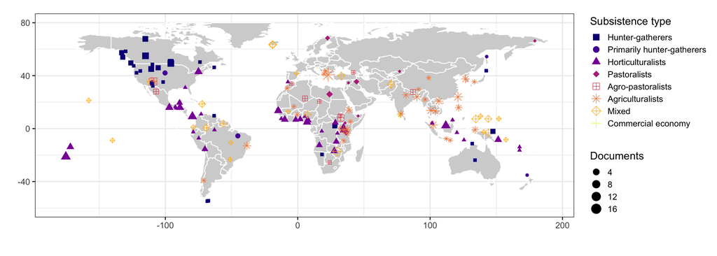

Figure 5: The geographical distribution of the culture sample. Point shape and color indicates eHRAF subsistence type and point size indicates the number of documents in the *Document dataset* for that culture. Axes are degrees latitude and longitude.

#### Reputation Domain Operational Definitions and Their Rationale for Inclusion

The inclusion of the 20 reputation domains, which constitute the main variables of our study, were developed *a priori* based on influential theories across the evolutionary human sciences; empirical results including cross-cultural and experimental studies; formal mathematical models; and ethnographic insights. While we do not contend that these are the only domains in which humans develop reputations, nor that there may not be other equally important reputation domains in particular cultural or social contexts, we do contend that these 20 reputation domains capture a very large slice of the evolutionary and social science literature discussing human reputations.

Here we elaborate on our rationale for selecting these reputation domains and our operational definitions of them, providing greater context and reference to existing literature (though our review here is not exhaustive). Below we provide the reputation domain names in bold and their operational definitions in italics, along with further commentary on their conceptualizations in the literature and our conceptualizations of their importance and interrelationships, grouped in five broad themes of the literature: 1) cooperation and prosocial investments; 2) communication, signalling, and cultural transmission; 3) competition within and between groups; 4) economics and individual productivity; and 5) reproduction and sexuality.

##### Cooperative and prosocial investments

Developmental and neuro-cognitive scientists, as well as evolutionary anthropologists, suggest that human uniqueness is predicated on an evolved social psychology dedicated to reasoning about conspecifics as intentional agents who have distinctly cooperative and prosocial motivations [23,42,43,70,83]. We follow this typology and differentiate cooperation from prosociality.

**Cooperation:** *Reputations based on the willingness, experience, capacities, or the likelihood an individual will (or will not) intentionally work together with or assist another individual or group or contribute to the efforts of another individual or group in order to achieve a joint goal or outcome.*

The above operational definition includes both cooperation (a behaviour which provides a benefit to another individual) and mutual benefits (behaviours that are beneficial to both an actor and recipient) as defined by [84].

Prosociality, however, is a broader class of emotions, motivations, and behaviours and can be exhibited in isolation without necessarily involving a cooperative dimension or context [85]. Theoretical perspectives rooted in gene-culture coevolution suggests humans are equipped with a universal norm-psychology, or, “a suite of psychological adaptations for inferring, encoding in memory, adhering to, enforcing and redressing violations of the shared behavioural standards of one’s community” [10], which underpins at least some between and within group variation in social norms. Cultural group selection processes are expected to promote the adoption and proliferation of social norms for prosocilaity [86–88].

**Prosociality:** *Reputations based on an individual’s willingness, experience, capacities or the likelihood one will (or will not) invest in group welfare or act in group-altruistic ways (i.e., in ways that are costly to the self). This definition includes emotions and dispositional characteristics that indicate a desire for sociality, such as friendliness.*

One key prosocial behaviour among humans (which likely has a long evolutionary history) is providing medical services and care to sick and wounded individuals [89–91]. A variety of specialized roles for medical service providers are common across human societies, including experts in plant medicine and midwifery [92–96].

**Medicine:** *Reputations for having (or not having) knowledge and ability to heal the self and others through naturalistic means.*

Across nonindustrial societies religious beliefs and practices are closely linked to many features of social life, including social influence and medical practices [97,98]. Shamanism, divination, supernatural healing, and various magical practices are a universal feature of human groups and psychology [78,99] and the abilities and formidability of practitioners are likely to be closely monitored by group members [100].

**Supernatural ability:** *Reputations for having supernatural abilities and capacities beyond “normal” abilities, including capacities rooted in physical displays with an important supernatural component (such as trance) or other non-physical abilities (augury, supernatural abilities in ritual, magic, etc.) This can include healing related to supernatural agency(ies) (includes individuals who dispossess these traits).*

##### Communication, signaling, and cultural transmission

Evolutionary biologists, anthropologists, and developmental psychologists have postulated that the evolution of language was made possible because of the fitness benefits associated with honest information transfers between those with knowledge and those who lack it [101–106]. While the content of honest information transfers differ across societies, uniquely human aspects include social learning about technology and behavioural regulation (e.g. norms, rules, punishments, rewards) [70]. We envision four domains emerging from this conceptual space: honesty, neural capital, oration, and teaching.

Honesty and honest signalling have been widely discussed across the evolutionary social and biological literature [22,107–109]. Experimental and modelling work among social insects has demonstrated that individuals displaying a signal incongruent with their behaviour (i.e., a dishonest signal) may be punished [110] and strong punishment systems inhibit dishonest signals, thereby affording the individual and group-level benefits associated with honest signalling [111,112]. Experimental work among humans (WEIRD, urban French participants) suggests smiles (viewed via video clips) rated as more honest predicted perceptions of trustworthiness and willingness to transfer money [113]. Facial cues and expressions communicate large amounts of social information and impact inter-individual trust [114]. Language allows people to share this useful information widely.

Charisma is one example of an emotional process by which individuals communicate and signal capacities, intentions, and affective states, with the effect of influencing others’ effective states and behaviours [115]. The evolution of charisma has been suggested to be based on its function as a credible signal of an individual’s ability to solve coordination problems and promote within group cooperation [116].

Whether or not individuals are providing honest signals to their group members (via charisma, facial expressions, language, etc.) can be evaluated over time and reputations for honesty can be one mechanism for monitoring and promoting inter-individual cooperation [117,118].

**Honesty**: *Reputations for the quality of being honest or not lying or intentionally deceiving others (as well as those dispossessing this trait – those who transmit non-truthful information, especially with an intent to deceive).*

There is likely to be substantial inter-individual variation in cognitive abilities and knowledge, due in part to the many genes influencing neural structures [119], the importance of developmental and ontogenic influences on brain development and function [120,121], and diversity in learning over the lifecourse [122,123]. Embodied capital conceptually captures all features of the phenotype including the physical body and it’s capacities such as strength and immune functioning, as well as psychological and cognitive capacities, such as intelligence, expertise, and knowledge [124,125]. Two sub-categories of embodied capital are sometimes differentiated: neural capital and somatic capital. Given the importance of intelligence and decision-making in human (and primate) evolution [126–128] variation in neural capital is likely to play a strong role in many aspects of social interaction, behaviours, and organization [129,130] and high levels of intelligence and knowledge have been found to be widely associated with influential individuals across human societies [36]. We therefore expect reputations associated with neural capital to be common and important for human sociality, partner choice, and mate preferences.

**Neural capital:** *Reputations for cognitive and neural-based dimensions of somatic or embodied capital, including reputations for generalized or specialized intelligence, special knowledge, cognitive abilities, and decision-making capacities (includes individuals who dispossess this trait).*

While the origins of human language are debated, it is likely an ancient trait and is considered a defining feature separating humans from other animals [70,131,132]. Not surprisingly, humans are differentiated and recognized for their ability to communicate through verbal language [7,133–136]. Furthermore, humans are keenly sensitive to rhetoric and oratory skills – the art of persuasive speaking [137] –- which is considered an important facet of leadership and organizational efficacy [116,138–141].

**Oration:** *Reputations for having (or not having) a superior ability to use language or other forms of vocalization in public and private contexts (includes individuals who dispossess this trait).*

Although the importance of teaching across human evolution has been debated [142,143], approaches to teaching rooted in evolutionary biology and adopting a definition of teaching rooted in natural pedagogy [144,145] (as we have done here) have provided robust evidence of the importance of teaching across diverse human societies, including hunter-gatherers and populations without a history or strong influence of Western, formal education [146–150]. Many models of cultural evolution also highlight the important role of learning biases, or the preferential selection of models or “teachers” based on social cues of capacity [7,71,151,152] and previous cross-cultural studies have documented the importance of teaching as a process of social learning among hunter-gatherers [146]. When available, learners should prefer and seek more effective and knowledgeable teachers [7] and reputations for teaching abilities and experiences can facilitate effective biased social learning.

**Teaching**: *Reputations for being a good teacher including all forms of teaching, defined as an informed individual modifying their behaviour for the learning benefit of a naive individual. Includes capacities to train and transmit specialized or generalized information. (includes individuals who dispossess this trait).*

Evolutionary anthropologists have argued that the evolution of structured human groups emerges from a psychological preference for cultural conformity (whether informational or normative conformity) [106,153]. Computational modelling demonstrates that adopting the most common behaviour or norms exhibited in society is adaptive [71] and that cultural conformity is favoured by natural selection under a range of conditions [72]. Humans also demonstrate a natural inclination to copy their peers and this behaviour arises from social motivations related to both the fear of punishment and the opportunity for rewards [154,155]. Although social norms and culturally appropriate behaviours can be variable, the expectation that group members learn and conform to culturally-specific expectations is expected to be widespread if not universal.

**Cultural conformity:** *Reputations based on excelling at, consistently demonstrating, or embodying skills or qualities preferentially valued within a particular cultural or social context. Includes culturally appropriate, preferred, and prescribed behaviours (e.g. willingness or ability to follow norms) (includes individuals who dispossess this trait).*

Admittedly, this reputation domain is broad and flexible but it is consistent with the theoretical literature and operationalized to capture the diversity of reputations associated with culturally specific behavioural expectations and social norms.

##### Competition within and between groups

Many human populations, including smaller-scale, nonindustrial societies and larger-scale, nation states regularly (or at least occasionally) engage in between-group conflict and warfare and much evidence suggests warfare has been a recurrent feature of human societies over deep time (cf. [74,156–161]). Therefore, when societies engage in between-group conflict cultural values and social norms can promote reputations for bravery [162,163] and such reputations can be driven by pressures associated with territoriality and sexual selection [164].

**Bravery:** *Reputations for the ability or disposition to voluntarily act when facing personal risk (in terms of agony, pain, loss, danger, uncertainty, or intimidation) in pursuit of a worthy goal, often in the face of fear (includes individuals who dispossess this trait).*

Status hierarchies are a ubiquitous feature of human social organization and represent an important arena for evolutionary processes, in particular due to their role in shaping access to resources and reproductive success [36,54,61,165–167].

**Social status:** *Reputations for having a high rank within social hierarchies, prestige, or esteem (or their opposite). Includes “global” social status, conceived broadly and likely dependent on multiple criteria. Separate from “Dominance” reputations.*

High status individuals are more likely to have higher quality social partners and variation in social networks (including size and quality) can allow well connected individuals to buffer risk, overcome social problems, and accomplish goals more effectively than individuals with low quality social networks [14,168–170].

**Social capital:** *Reputations for having a large and/or strong social support network including having many social partners, kin or allies and having social partners, kin, or allies who are of high quality (includes individuals who dispossess this trait).*

There is a long history in the social sciences suggesting human status hierarchies are primarily shaped by social strategies rooted in dominance and/or prestige [141,171–173]; for review see [174]. Much recent scholarship within the evolutionary human sciences has drawn on and developed from Henrich and Gil-White [7], which incorporated cultural evolutionary processes and social selection into evolutionary models of prestige and status. There are important differences, similarities, and nuances among the various theoretical models of human status drawing on the dominance-prestige (also dual-model or dual-strategy) framework which we do not review here, however, a clear consensus from this literature is that individuals and communities can develop or promote reputations based on qualities associated with both dominance – the ability to achieve priority access to resources or social influence through coercion, threat, intimidation, or displays of force – and/or prestige – the ability to achieve social influence through social support, preference, persuasion, or global representations of respect and esteem [7,36,60,63,175–177].

Dominance hierarchies, or linear or other organizational systems of conspecific group members which regulate priority of access to contested resources, are widespread across social species [61,178]. They are often thought to emerge and be maintained because of their individual and group-level benefits – with an established and agreed upon hierarchy individuals do not need regularly pay the contest of agonistic competition over resources [177,179,180]. A key component of dominance hierarchies is that they are generally agreed upon and the relative ranking of individuals is known. Some evidence suggests humans are able to perceive differences in physical formidability via various visual cues without social or behavioural information [181,182]. From this point of view, reputations for coercive abilities may be less salient or less necessary relative to other more cryptic traits or propensities. Alternatively, reputations for coercive ability or aggressiveness can be useful in a number of partner-choice contexts including intra and inter-group conflicts [183,184] and in choosing leaders of cooperative activities who can more effectively punish free-riders [185,186].

**Coercive ability:** *Reputations based on others fear, threats, or intimidation rooted in power-imbalances and differences in physical formidability, and when these actions are associated with greater access to contested resources and/or social influence and control (includes individuals who dispossess this trait).*

Individuals may become recognized as highly coercive because of their physical size in the absence of aggressive displays or behaviour, as such we distinguish aggressiveness and somatic capital as separate from coercive ability [187].

Aggressive behaviour can be costly for anyone involved. Aggressiveness can be a useful social strategy [188,189], propensities and capacities for aggression are variable between individuals [25,190], and thresholds for aggression are potentially situation and context-dependent [191,192]. Reliable and up-to-date information on inter-individual aggressiveness can potentially be life saving.

**Aggressiveness:** *Reputations for a propensity to act aggressively and agonistically, though which may not include control or influence (includes individuals who dispossess this trait).*

Evidence for psychological adaptations for assessing variation in physical formidability (discussed above) underscore the importance of being able to reliably identify stronger (or weaker) members of a group. Reputations for physical strength and other physical capacities would represent a low-cost method for confirming or supplementing individual intuition or observation. Reputations for physical formidability or other somatic capital, for example, could be important in the formation of collective labour groups [139,193].

**Somatic capital:** *Reputations for beneficial and positive physiological traits including health, strength, agility and dexterity (includes individuals who dispossess this trait).*

##### Economics and individual productivity

Reputations can be based purely on the outputs and products of individual efforts and behaviours, as opposed to their capacities, per se, e.g., reputations for delivering hunted meat (not the ability to hunt), reputations for parental or allo-parental care (not the ability to care for children), reputations for earning wages (not the ability to perform a task within a wage labour context), reputations for producing cultivated foods (not the reputation for being a knowledgeable farmer/gardener). Producing surplus goods is a commonly valued behaviour across societies, and especially among subsistence-based populations [194–197].

**Industriousness:** *Reputations based on productive outputs from activities such as subsistence and other economic efforts, domestic work, recreational accomplishments, etc., including past and current productivity (includes individuals who dispossess this trait).*

Despite immense variability in economic systems, property, and ownership, across societies, most (if not all) human societies exhibit inter-individual and inter-household variation in some form of material resources, which can include clothes, structures, livestock, tools, currency, and prestige goods [198] and such variation likely has deep evolutionary history [199]. Even among populations with little material property and strong norms of sharing, ownership of important tools or prestige goods can be a sign of social success and can shape social relationships, patterns of indebtedness, and reciprocity [200,201]

**Material capital:** *Reputations for having high levels of material wealth, including all forms of material wealth and currencies, such as money, territory, prestige goods, property, having food reserves, and other material resources (includes individuals who dispossess this trait).*

##### Reproduction and sexuality

Humans are extraordinary for our ability to form long-term pair bonds [202]. One class of models suggests that pair-bonding emerged in the context of mate guarding (e.g., [55]). If this were the case, then we would expect an evolved psychology for assessing female sexual fidelity, sexuality, and parental investment.

Cross-culturally, there are many social institutions which function to mandate and regulate the sexuality of women and communicate information about women’s sexuality to the group [203,204] and various theoretical models and ethnographic cases illustrate gender asymmetries in values for sexual fidelity and suppression of female sexuality [35,205].

**Sexual fidelity:** *Reputations for fidelity, sexual exclusivity, and maintaining physical commitment within a marriage or sexual relationship (includes individuals who dispossess this trait).*

Individuals in a marriage or mateship face numerous conflicts of interest, including over current and future reproduction. Despite the deeply entrenched and superficial evolutionary view that women should be coy and men should be promiscuous, women (and females across many species) can benefit from high sociosexuality and multiple partners [59,206].

**Sociosexuality:** *Reputations for having many sexual partners and/or willingness to engage in sexual activity or develop multiple sexual/romantic relationships (e.g., high sociosexuality). (includes individuals who dispossess this trait, e.g., low sociosexuality).*

Some empirical studies, including among rural hunter-gatherers and urban Western participants, suggest that men reduce their parental investment in the context of increased paternal uncertainty [207,208]. Skills in parental investment and motherhood are expected to be a key domain in women’s intrasexual competition across nonindustrial societies [209,210] and both men and women are expected to generally favour skills and propensities for parental investment in their long-term mates [36], yet parental investment strategies are variable within and between populations [211,212].

**Parental care:** *Reputations for being a good parent, successfully raising many/quality children, and/or investing a lot of time, resources, and energy in raising children. (includes individuals who dispossess this trait).*

### eHRAF search strategy

We conducted an “Advanced Search” of the keyword “reputation” with any of the following OCM subjects: *Social Personality* (156), *Personality Traits* (157), or *Status, Role, and Prestige* (554).

There is no single OCM subject code for “reputation,” however, these three codes were deemed to collectively and parsimoniously embody key theoretical dimensions of reputations, given that they capture phenomena such as, “enhancement and defense of the self,” “interpretations of personality as reflecting social norms” (156); “prevalence of cooperativeness and competitiveness,” “cultural selectivity with reference to personality traits,” (157); “prevalence of ascribed and achievable statuses”, and “statuses adapted to particular personality type” (554). By coupling the keyword “reputation” with these codes, the search is more likely to avoid paragraphs discussing other, non-reputation based forms of social capital, such as ascribed statues [213,214]. In crafting an eHRAF search, researchers face a trade off in capturing a sufficiently broad range of ethnographic information while also limiting the sample to a manageable range. Our search produced 1383 paragraphs in 670 documents from 242 cultures. This paragraph sample size is within the range of studies with similar methodologies (e.g., [66] produced 1426 paragraphs after inclusion criteria; [215] produced 474 paragraphs; [36] produced 1212 paragraphs after inclusion criteria).

### Example ethnographic coding

To briefly describe our coding process, we present an example of a text excerpt and our coding drawn from Smithson’s [216] research on Havasupai women:

> There are in the tribe perhaps two or three other women who have few friends, who are considered difficult to get along with, or who bear strong antagonisms toward a few individuals. Other women, as a rule, avoid trouble with such a person by associating with her as little as possible. Even women of this reputation, however, have their own circles of relatives or close friends, sometimes outside the Havasupai tribe, with whom they do maintain pleasant social relations.

Through methods described above, this excerpt was coded as providing evidence for female cooperativeness (“are considered difficult to get along with”), female prosociality (“with whom they maintain pleasant social relations”), female social capital (“have few friends”), and female aggression (“who bear strong antagonisms”).

### Cluster analysis

This analysis begins with each element in individual clusters (here, vectors of coded data for each reputation domain). Then, a distance metric is used to combine the two closest clusters into a single cluster, the next two closest clusters are then combined, and so forth, until all elements belong to a single cluster. We computed correlation distances between our binary reputation domain vectors ($1-cor$), and agglomerated using the Ward D2 algorithm. We assessed the robustness of clusters using the pvclust package [40,217], which computes an approximately unbiased probability that a cluster appears in bootstrapped samples (AU values, see below), using 10,000 bootstrapped samples. Note that cluster analysis results are often sensitive to the distance metric and agglomeration algorithm used. Our choices here produced robust clusters that closely matched theory.

### Additional descriptive results

Table S1 reports the total number of documents in the *Document dataset* for each eHRAF subsistence type as well the total count of coded reputation domains, across all domains, for each subsistence type. Although the number of documents and the counts of evidence for coded reputation domains varies across subsistence types, the average number of of coded reputation domains per document is fairly consistent across subsistence types.

Table S2 reports the total count of coded reputation domains by gender coding.

Table 1: Total number of documents, counts of evidence for reputation domains, and cultures by subsistence type.

| Subsistence type | Number of cultures | Number of documents | Count of coded domains | Domain-per-document ratio |
| --- | --- | --- | --- | --- |
| Horticulturalists | 41 | 94 | 353 | 3.76 |
| Agriculturalists | 34 | 84 | 332 | 3.95 |
| Hunter-gatherers | 28 | 48 | 182 | 3.79 |
| Mixed | 25 | 44 | 180 | 4.09 |
| Agro-pastoralists | 10 | 22 | 84 | 3.82 |
| Pastoralists | 9 | 17 | 75 | 4.41 |
| Primarily hunter-gatherers | 5 | 8 | 34 | 4.25 |
| Commercial economy | 1 | 2 | 12 | 6.00 |

Table 2: Total number of coded reputation domains by gender type.

| Gender coding | Total number of coded domains |
| --- | --- |
| Male | 695 |
| Neutral | 418 |
| Female | 139 |

### Assessing gender-differences in evidence for reputation domains

Table S3 reports results from binomial GLMM regression models used to assess gender differences in evidence for reputation domains. For all reputation domains for which there was male-specific and female-specific evidence (18 of 20 domains which did not include *Bravery* or *Honesty*), we fit two binomial GLMMs with the binary coded reputation domain as the outcome ($0$, no evidence; $1$, evidence for). The first, intercept-only model included random effects for document ID nested within culture ID, to account for the repeated measures of gender-specific evidence per document and the potential multiple documents per culture, as well as random effects for the culture’s language family (retrieved from The Ethnographic Atlas via D-PLACE, https://d-place.org/ or other sources in unavailable). We compared these intercept-only models to a similar model with identical random effects but which included a term for gender coding as a covariate by assessing the difference in AIC. Gender was deemed to be a predictor of evidence for reputation domains which produced an $AIC \Delta <-2$ in this model comparison framework. Table S3 below reports the AIC values and differences for these models as well as the p-value for the Gender-term and adjusted p-values to account for false discovery rates using the Benjamini & Hochberg “BH” method (and the p.adjust function in the stats package [218]). This table also reports the total counts of evidence for each reputation domain. Additional details included in the main text.

Table 3: Results of regression models testing for gender differences across reputation domains

| Variable | Total count of evidence | Intercept-only AIC | Gender-term AIC | AIC difference | Gender-term p value | Gender-term adjusted p value |
| --- | --- | --- | --- | --- | --- | --- |
| Social status | 128 | 740.935 | 648.073 | -92.862 | 0.000 | 0.000 |
| Prosociality | 136 | 784.824 | 727.832 | -56.991 | 0.000 | 0.000 |
| Material capital | 80 | 545.121 | 488.133 | -56.988 | 0.000 | 0.000 |
| Coercive ability | 51 | 403.362 | 348.388 | -54.974 | 0.000 | 0.000 |
| Neural capital | 123 | 729.231 | 678.390 | -50.842 | 0.000 | 0.000 |
| Social capital | 59 | 448.639 | 414.737 | -33.902 | 0.000 | 0.000 |
| Supernatural ability | 83 | 564.379 | 539.753 | -24.626 | 0.000 | 0.000 |
| Cultural conformity | 138 | 781.264 | 757.609 | -23.655 | 0.000 | 0.000 |
| Industriousness | 105 | 657.542 | 639.129 | -18.413 | 0.000 | 0.000 |
| Aggressiveness | 54 | 421.263 | 405.591 | -15.672 | 0.000 | 0.001 |
| Oration | 35 | 306.939 | 291.969 | -14.970 | 0.000 | 0.000 |
| Cooperation | 42 | 350.372 | 336.370 | -14.003 | 0.001 | 0.002 |
| Sexual fidelity | 27 | 252.349 | 240.335 | -12.014 | 0.003 | 0.004 |
| Somatic capital | 35 | 306.942 | 297.406 | -9.535 | 0.003 | 0.004 |
| Medicine | 32 | 283.946 | 276.279 | -7.667 | 0.018 | 0.021 |
| Teaching | 7 | 88.029 | 87.514 | -0.515 | 0.144 | 0.163 |
| Sociosexuality | 37 | 317.936 | 319.040 | 1.104 | 0.239 | 0.253 |
| Parental care | 7 | 80.598 | 83.545 | 2.947 | 0.627 | 0.627 |

The results in Table S3 and Figure 1B highlight the results from the *Sexual fidelity* and *Sociosexuality* (given the former is the only reputation domain to exhibit a female bias in available evidence and the later is the only reputation domain which did not exhibit a gender bias [excluding *Parental care* and *Teaching* which did not produce much evidence]). Also, Aim 2 focuses on such gender differences. To supplement results reported in Table S3 we report the coefficients from the *Sexual fidelity* and *Sociosexuality* gender-test models in Table S4.

Results reported in Table S4 suggest gender does not predict evidence for *Sociosexuality* and both male-specific and gender neutral evidence is significantly lower than female-specific evidence, for *Sexual fidelity*.

Table 4: Term estimates and CIs for the gender-bias test models for the sexuality reputation domain variables.

| Reputation domain outcome | Gender-term predictor | Estimate | Standard error | Confidence interval (low) | Confidence interval (high) | Predictor level p-value | Predictor level adjusted p-value |
| --- | --- | --- | --- | --- | --- | --- | --- |
| sociosexuality | (Intercept) | -2.93 | 0.27 | -3.47 | -2.40 | 0.00 | 0.00 |
| sociosexuality | sexMale | -0.46 | 0.40 | -1.23 | 0.32 | 0.25 | 0.25 |
| sociosexuality | sexNeutral | -0.67 | 0.42 | -1.49 | 0.16 | 0.11 | 0.17 |
| sexual fidelity | (Intercept) | -2.75 | 0.29 | -3.31 | -2.19 | 0.00 | 0.00 |
| sexual fidelity | sexMale | -0.98 | 0.45 | -1.87 | -0.10 | 0.03 | 0.03 |
| sexual fidelity | sexNeutral | -2.25 | 0.75 | -3.73 | -0.78 | 0.00 | 0.00 |

### Bias assessment

In an attempt to assess if features of the ethnographic record, rather than patterns of meaningful cultural diversity, influenced our discovery of evidence for reputation domains, we used three metadata measures of the ethnographic record (meta-ethnographic measures) in predicting evidence for our coded reputation domain variables. The three meta-ethnographic measures were: the presence of a female coauthor in source documents, the year of publication of source documents, and the total pages of published ethnography available for each culture in the eHRAF database.

There has been much discussion on the degree of intrinsic bias in the ethnographic record due to the majority of ethnographers being men who may have various gender-specific biases when conducting and reporting ethnographic research. Furthermore, much of social and economic life in nonindustrial societies is gender-segregated, so, even if male ethnographers were “bias-free” it is likely that their opportunities to observe female-specific behaviour and social domains were limited. Of our 319 documents, 90 featured at least one female coauthor.

On the whole, the focus and general interest of social science disciplines change over time. Starting at the very beginning of the ethnographic record, there is a case to be made that a general historical trend, at least partially, influences the content of ethnography. Moreover, general, more global historical changes, such as the industrial revolution, periods of international wartime, the feminist revolution, the postmodern revolution, and the digital age, etc., could all impact the content of ethnography produced at the time (or later times). Simply, historical and temporal forces can shape the content of the ethnographic record. The oldest of our 319 documents was published in 1857, the most recent in 2008, with a median publication date of 1974.

The eHRAF is a subset of the physical HRAF collections. The HRAF, despite being the most comprehensive source of ethnography available, does not include every ethnographic document in existence. The collection of documents available for each culture in the eHRAF are only a portion of the total ethnographic documents available for that culture. Logically, the greater the scope of ethnographic materials included in the eHRAF the greater the likelihood those ethnographic materials include content related to any particular subject (e.g., any particular reputation domain). The total pages of ethnography included in the eHRAF can serve as a proxy for the total “effort” of ethnographic coverage for each culture included in the eHRAF.

To assess if these three meta-ethnographic variables influenced our discovery of evidence, we fit two binomial GLMMs for each of the 20 reputation domains (similar to our assessment of gender differences): an intercept only model, which only included random effects for culture and language family, and a similar model which included terms for the presence of a female coauthor for the source documents (0/1), the year of publication for the source document (scaled), and the total number of pages of ethnography in the eHRAF for the culture (scaled). The outcome was the presence of supporting evidence for each reputation domain, independent of gender coding (0/1). We compared the two models using AIC and determined the meta-ethnographic variables offer predictive utility when $AIC \Delta < -2$.

Table S5 presents results of the fitted models and their comparisons. The models including the meta-ethnographic predictor variables demonstrated an improved fit for four of the reputation domains: *Cultural conformity*, *Honesty*, *Supernatural ability*, and *Bravery*.

Table 5: Results of regression models testing for biases by meta-ethnographic measures across reputation domains

| Variable | Intercept-only AIC | Meta-ethnographic AIC | AIC difference | Female coauthor p value | Female coauthor adjusted p value | Page total p value | Page total adjusted p value | Publication year p value | Publication year adjusted p value |
| --- | --- | --- | --- | --- | --- | --- | --- | --- | --- |
| Cultural conformity | 433.08 | 428.77 | -4.31 | 0.15 | 0.59 | 0.60 | 0.79 | 0.01 | 0.12 |
| Honesty | 194.23 | 190.37 | -3.86 | 0.86 | 0.94 | 0.23 | 0.62 | 0.01 | 0.12 |
| Supernatural ability | 362.73 | 359.62 | -3.11 | 0.07 | 0.47 | 0.33 | 0.62 | 0.06 | 0.25 |
| Bravery | 258.68 | 255.63 | -3.05 | 0.04 | 0.45 | 0.31 | 0.62 | 0.11 | 0.36 |
| Social capital | 307.26 | 305.88 | -1.39 | 0.70 | 0.94 | 0.26 | 0.62 | 0.02 | 0.12 |
| Prosociality | 427.89 | 426.98 | -0.91 | 0.03 | 0.45 | 0.52 | 0.79 | 0.57 | 0.76 |
| Cooperation | 250.33 | 249.49 | -0.84 | 0.49 | 0.88 | 0.57 | 0.79 | 0.03 | 0.17 |
| Sociosexuality | 229.32 | 229.78 | 0.47 | 0.32 | 0.71 | 0.15 | 0.62 | 0.23 | 0.51 |
| Coercive ability | 281.14 | 282.15 | 1.01 | 0.23 | 0.71 | 0.13 | 0.62 | 0.63 | 0.76 |
| Medicine | 206.89 | 208.13 | 1.24 | 0.30 | 0.71 | 0.34 | 0.62 | 0.15 | 0.41 |
| Sexual fidelity | 188.68 | 190.52 | 1.83 | 0.10 | 0.48 | 0.46 | 0.77 | 0.60 | 0.76 |
| Parental care | 65.34 | 67.57 | 2.23 | 0.82 | 0.94 | 0.13 | 0.62 | 0.77 | 0.81 |
| Neural capital | 420.90 | 423.93 | 3.03 | 0.72 | 0.94 | 0.13 | 0.62 | 0.66 | 0.76 |
| Social status | 422.48 | 426.33 | 3.86 | 0.90 | 0.94 | 0.84 | 0.96 | 0.16 | 0.41 |
| Aggressiveness | 292.64 | 296.56 | 3.92 | 0.78 | 0.94 | 0.25 | 0.62 | 0.59 | 0.76 |
| Teaching | 68.94 | 73.17 | 4.23 | 0.31 | 0.71 | 0.96 | 0.96 | 0.62 | 0.76 |
| Somatic capital | 225.29 | 229.79 | 4.49 | 1.00 | 1.00 | 0.29 | 0.62 | 0.91 | 0.91 |
| Material capital | 355.01 | 359.95 | 4.94 | 0.46 | 0.88 | 0.80 | 0.96 | 0.56 | 0.76 |
| Industriousness | 402.58 | 408.13 | 5.54 | 0.83 | 0.94 | 0.96 | 0.96 | 0.54 | 0.76 |
| Oration | 224.95 | 230.65 | 5.70 | 0.74 | 0.94 | 0.91 | 0.96 | 0.68 | 0.76 |

We then reviewed the results of single term deletions (using the drop1 function) of the meta-ethnographic models for each of these four potentially biased reputation domains. Table S6 reports the drop in AIC value in the meta-ethnographic bias model for each potentially biased reputation domain (represented in the columns) and the resulting AIC value after dropping each of the three meta-ethnographic bias measures (represented in the rows). Table S6 suggests, for *Cultural conformity* dropping *Publication year* reduces model fit ($AIC \Delta = - 5.13$) but dropping the other two meta-ethnographic measures does not impact fit; similarly for *Honesty* dropping *Publication year* reduces model fit ($AIC \Delta = - 5.88$) but dropping the other two measures does not; for *Supernatural ability* no single term deletion impacts models fit; and for *Bravery* dropping *Female coauthor* reduces model fit ($AIC \Delta = - 2.77$) but dropping the other two measures does not. We then investigated the adjusted p-values (which account for the multiple comparisons) for these models and terms in Table S6, which suggests none of the meta-ethnographic predictors are statistically significant predictors (at $\alpha = .05$). We therefore conclude the meta-ethnographic measures are not strongly influencing our discovery of evidence for reputation domains.

Table 6: Results of single term deletions of meta-ethnographic bias models from those reputation domains with potentially biased evidence.

|  | Cultural conformatity | Honesty | Supernatural ability | Bravery |
| --- | --- | --- | --- | --- |
| Meta-ethnographic (Full) AIC | 428.77 | 190.37 | 359.62 | 255.63 |
| Female coauthor (Dropped) AIC | 428.94 | 188.41 | 361.32 | 258.40 |
| Page total (Dropped) AIC | 427.06 | 189.73 | 358.67 | 254.83 |
| Publication year (Dropped) AIC | 433.90 | 196.25 | 361.28 | 256.14 |

We replicated the above bias assessment, but looking specifically at discovery of female-specific evidence as outcomes for each reputation domain (given the divergence of supporting evidence between male and female specific reputation domains in general). These analyses identified five potential reputation domains in which female-specific evidence may be biases (based on AIC model comparison): *Cooperation*, *Cultural conformity*, *Prosociality*, *Medicine*, and *Oration* (however, note the very low levels of female-specific evidence for most of these reputation domains).

Table 7: Results of regression models testing for biases by meta-ethnographic measures across female-specific evidence for reputation domains.

| Variable | Counts of evidence | Intercept-only AIC | Meta-ethnographic AIC | AIC difference | Female coauthor p value | Female coauthor adjusted p value | Page total p value | Page total adjusted p value | Publication year p value | Publication year adjusted p value |
| --- | --- | --- | --- | --- | --- | --- | --- | --- | --- | --- |
| Cooperation | 4 | 48.83 | 43.05 | -5.77 | 1.00 | 1.00 | 0.68 | 0.99 | 0.31 | 0.55 |
| Cultural conformity | 21 | 154.41 | 151.47 | -2.95 | 0.02 | 0.14 | 0.94 | 0.99 | 0.16 | 0.55 |
| Prosociality | 10 | 94.13 | 91.27 | -2.86 | 0.01 | 0.14 | 0.95 | 0.99 | 0.29 | 0.55 |
| Medicine | 3 | 39.52 | 37.15 | -2.37 | 1.00 | 1.00 | 0.17 | 0.82 | 0.27 | 0.55 |
| Oration | 5 | 54.98 | 52.64 | -2.33 | 0.22 | 0.66 | 0.87 | 0.99 | 0.13 | 0.55 |
| Social capital | 3 | 39.81 | 38.04 | -1.78 | 0.15 | 0.66 | 0.11 | 0.82 | 0.67 | 0.82 |
| Supernatural ability | 9 | 87.59 | 88.30 | 0.71 | 0.31 | 0.66 | 0.10 | 0.82 | 0.78 | 0.82 |
| Sociosexuality | 17 | 138.05 | 138.98 | 0.93 | 0.33 | 0.66 | 0.19 | 0.82 | 0.22 | 0.55 |
| Aggressiveness | 6 | 65.34 | 66.45 | 1.12 | 0.07 | 0.41 | 0.42 | 0.82 | 0.75 | 0.82 |
| Industriousness | 16 | 132.12 | 133.80 | 1.68 | 0.25 | 0.66 | 0.39 | 0.82 | 0.22 | 0.55 |
| Teaching | 1 | 19.49 | 21.20 | 1.71 | 1.00 | 1.00 | 0.40 | 0.82 | 0.69 | 0.82 |
| Coercive ability | 1 | 19.49 | 21.46 | 1.97 | 1.00 | 1.00 | 0.83 | 0.99 | 0.17 | 0.55 |
| Material capital | 2 | 30.20 | 32.77 | 2.57 | 0.71 | 1.00 | 0.97 | 0.99 | 0.19 | 0.55 |
| Social status | 4 | 46.79 | 50.33 | 3.53 | 0.29 | 0.66 | 0.99 | 0.99 | 0.30 | 0.55 |
| Parental care | 3 | 39.86 | 43.95 | 4.09 | 0.84 | 1.00 | 0.35 | 0.82 | 0.53 | 0.82 |
| Sexual fidelity | 18 | 142.74 | 147.02 | 4.28 | 0.42 | 0.69 | 0.46 | 0.82 | 0.62 | 0.82 |
| Neural capital | 12 | 107.81 | 112.38 | 4.57 | 0.74 | 1.00 | 0.34 | 0.82 | 0.90 | 0.90 |
| Somatic capital | 4 | 48.82 | 53.61 | 4.79 | 0.39 | 0.69 | 0.69 | 0.99 | 0.68 | 0.82 |

As before, we also investigated single term deletions of these models. Considering the low levels of female-specific evidence (for *Cooperation*, *Medicine*, and *Oration* especially) and the adjusted p values (all of which are $>> 0.05$) of these terms for these models, we concluded these meta-ethnographic measures are not influencing the discovery of female-specific evidence in our data.

Table 8: Results of single term deletions of meta-ethnographic bias models from those reputation domains with potentially biased female specific evidence.

|  | Cooperation | Cultural conformatity | Prosociality | Medicine | Oration |
| --- | --- | --- | --- | --- | --- |
| Meta-ethnographic (Full) AIC | 43.05 | 151.47 | 91.27 | 37.15 | 52.64 |
| Female coauthor (Dropped) AIC | 50.57 | 155.39 | 96.05 | 36.91 | 52.57 |
| Page total (Dropped) AIC | 41.19 | 149.47 | 89.27 | 40.07 | 50.67 |
| Publication year (Dropped) AIC | 42.44 | 151.73 | 90.63 | 36.76 | 55.96 |

In conclusion, there were three possible reputation domains for which our discovery of evidence *may* have been influenced by meta-ethnographic measures: Publication year influencing overall evidence for *Cultural conformity* and *Honesty*, and female coauthorship influencing overall evidence for *Bravery*. Effects are generally small (the largest being the absence of female coauthors and evidence for bravery, $\beta = -0.93$) and adjusted p-values suggest effects are not statistically significant. We report the coefficients from these three models in Table S9 to supplement results in Table S6.

Table 9: Term estimates and CIs for the three reputation domain variables potentially biased by metha-ethnographic measures, as indicated by AIC model comparison.

| Reputation domain outcome | Meta-ethnographic predictor | Estimate | Standard error | Confidence interval (low) | Confidence interval (high) |
| --- | --- | --- | --- | --- | --- |
| cultural_conformity | (Intercept) | -0.42 | 0.15 | -0.72 | -0.12 |
| cultural_conformity | female_coauthorship | 0.38 | 0.26 | -0.13 | 0.89 |
| cultural_conformity | scale(N_pages) | -0.07 | 0.13 | -0.32 | 0.18 |
| cultural_conformity | scale(publication_year) | 0.33 | 0.13 | 0.08 | 0.58 |
| honesty | (Intercept) | -2.47 | 0.27 | -3.01 | -1.94 |
| honesty | female_coauthorship | -0.08 | 0.46 | -0.98 | 0.81 |
| honesty | scale(N_pages) | 0.21 | 0.17 | -0.13 | 0.54 |
| honesty | scale(publication_year) | 0.73 | 0.29 | 0.16 | 1.31 |
| bravery | (Intercept) | -1.67 | 0.22 | -2.10 | -1.24 |
| bravery | female_coauthorship | -0.93 | 0.47 | -1.85 | -0.02 |
| bravery | scale(N_pages) | -0.22 | 0.22 | -0.65 | 0.21 |
| bravery | scale(publication_year) | -0.25 | 0.16 | -0.55 | 0.06 |

## References

1. Alexander RD. 1987 *The biology of moral systems*. New York: De Gruyter.

2. Barclay P. 2015 Reputation. In *The Handbook of Evolutionary Psychology* (ed D Buss), pp. 810–828. New York: John Wiley & Sons.

3. Macfarlan SJ, Lyle HF. 2015 Multiple reputation domains and cooperative behaviour in two Latin American communities. *Phil. Trans. R. Soc. B* **370**, 20150009.

4. Barclay P. 2013 Strategies for cooperation in biological markets, especially for humans. *Evolution and Human Behavior* **34**, 164–175. (doi:10.1016/j.evolhumbehav.2013.02.002)

5. Milinski M. 2016 Reputation, a universal currency for human social interactions. *Philosophical Transactions of the Royal Society B: Biological Sciences* **371**, 20150100. (doi:10.1098/rstb.2015.0100)

6. Sugden R. 2005 *The Economics of Rights, Co-operation and Welfare*. Palgrave Macmillan UK. (doi:10.1057/9780230536791)

7. Henrich J, Gil-White FJ. 2001 The evolution of prestige: Freely conferred deference as a mechanism for enhancing the benefits of cultural transmission. *Evolution and Human Behavior* **22**, 165–196.

8. Buss DM, Durkee PK, Shackelford TK, Bowdle BF, Schmitt DP, Brase GL, Choe JC, Trofimova I. 2020 Human status criteria: Sex differences and similarities across 14 nations. *Journal of Personality and Social Psychology*, No Pagination Specified–No Pagination Specified. (doi:10.1037/pspa0000206)

9. Glowacki L. 2020 The Emergence of locally adaptive institutions: Insights from traditional social structures of East African pastoralists. *Biosystems*, 104257. (doi:10.1016/j.biosystems.2020.104257)

10. Chudek M, Henrich J. 2011 Culture-gene coevolution, norm-psychology and the emergence of human prosociality. *Trends Cogn Sci* **15**, 218–26. (doi:10.1016/j.tics.2011.03.003)

11. Gintis H. 2000 Strong Reciprocity and Human Sociality. *Journal of Theoretical Biology* **206**, 169–179. (doi:10.1006/jtbi.2000.2111)

12. Subiaul F, Vonk J, Okamoto-Barth S, Barth J. 2008 Do chimpanzees learn reputation by observation? Evidence from direct and indirect experience with generous and selfish strangers. *Animal Cognition* **11**, 611–623. (doi:10.1007/s10071-008-0151-6)

13. Nowak MA, Sigmund K. 1998 Evolution of indirect reciprocity by image scoring. *Nature* **393**, 573–577. (doi:10.1038/31225)

14. Macfarlan SJ, Remiker M, Quinlan R. 2012 Competitive Altruism Explains Labor Exchange Variation in a Dominican Community. *Current Anthropology* **53**, 118–124. (doi:10.1086/663700)

15. Hess NH, Hagen EH. 2006 Psychological adaptations for assessing gossip veracity. *Human Nature* **17**, 337–354.

16. Giardini F, Wittek R. 2019 *The Oxford handbook of gossip and reputation*. New York: Oxford University Press.

17. Enquist M, Ghirlanda S, Eriksson K. 2011 Modelling the evolution and diversity of cumulative culture. *Philosophical Transactions of the Royal Society B: Biological Sciences* **366**, 412–423. (doi:10.1098/rstb.2010.0132)

18. Barclay P. 2004 Trustworthiness and competitive altruism can also solve the ‘tragedy of the commons’. *Evolution and Human Behavior* **25**, 209–220. (doi:10.1016/j.evolhumbehav.2004.04.002)

19. Panchanathan K, Boyd R. 2004 Indirect reciprocity can stabilize cooperation without the second-order free rider problem. *Nature* **432**, 499.

20. Macfarlan SJ, Quinlan R, Remiker M. 2013 Cooperative behaviour and prosocial reputation dynamics in a Dominican village. *Proceedings of the Royal Society B: Biological Sciences* **280**, 20130557. (doi:10.1098/rspb.2013.0557)

21. Lyle HF, Smith EA. 2014 The reputational and social network benefits of prosociality in an Andean community. *Proceedings of the National Academy of Sciences* **111**, 4820–4825. (doi:10.1073/pnas.1318372111)

22. Hawkes K, Bird RB. 2002 Showing off, handicap signaling, and the evolution of men’s work. *Evolutionary Anthropology* **11**, 58–67.

23. Fiske ST, Cuddy AJC, Glick P. 2007 Universal dimensions of social cognition: Warmth and competence. *Trends in Cognitive Sciences* **11**, 77–83. (doi:10.1016/j.tics.2006.11.005)

24. Benard S. 2013 Reputation systems, aggression, and deterrence in social interaction. *Social Science Research* **42**, 230–245. (doi:10.1016/j.ssresearch.2012.09.004)

25. Hess NH, Hagen EH. 2006 Sex differences in indirect aggression Psychological evidence from young adults. *Evolution and Human Behavior* **27**, 231–245.

26. Hess NH, Hagen EH. 2019 Gossip, reputation, and friendship in within-group competition: An evolutionary perspective. In *Handbook of Reputation and Gossip*, Oxford University Press.

27. Buss DM, Dedden LA. 1990 Derogation of Competitors. *Journal of Social and Personal Relationships* **7**, 395–422. (doi:10.1177/0265407590073006)

28. Davis A, Vaillancourt T, Arnocky S, Doyel R. 2019 Women’s Gossip as an Intrasexual Competition Strategy. In *The Oxford Handbook of Gossip and Reputation* (eds F Giardini, R Wittek), (doi:10.1093/oxfordhb/9780190494087.013.16)

29. Nowak MA. 2006 Five rules for the evolution of cooperation. *Science (New York, N.y.)* **314**, 1560–1563. (doi:10.1126/science.1133755)

30. Post ER, Macfarlan SJ. 2020 Tracking Cross-Cultural Gender Bias in Reputations. *Cross-Cultural Research* **54**, 346–363. (doi:10.1177/1069397120910429)

31. Mukhopadhyay CC, Higgins PJ. 1988 Anthropological studies of women’s status revisited: 1977-1987. *Annu Rev Anthropol* **17**, 461–95. (doi:10.1146/annurev.an.17.100188.002333)

32. Abu-Lughod L. 1990 Can There Be A Feminist Ethnography? *Women & Performance: a journal of feminist theory* **5**, 7–27. (doi:10.1080/07407709008571138)

33. Ember CR. 2007 Using the HRAF Collection of Ethnography in Conjunction With the Standard Cross-Cultural Sample and the Ethnographic Atlas. *Cross-Cultural Research* **41**, 396. (doi:10.1177/1069397107306593)

34. Garfield Z, Macfarlan S, Schacht R, Post E, Ingram D, Uehling A. 2021 Zhgarfield/reputationdiversitydata: Initial release of the reputationdiversitydata package. (doi:10.5281/zenodo.4740791)

35. Syme KL, Garfield ZH, Hagen EH. 2015 Testing the bargaining vs. Inclusive fitness models of suicidal behavior against the ethnographic record. *Evolution and Human Behavior* **37**, 179–192. (doi:10.1016/j.evolhumbehav.2015.10.005)

36. Garfield ZH, Hubbard H Robert, Hagen EH. 2019 Evolutionary models of leadership: Tests and synthesis. *Human Nature* **30**, 23–58. (doi:10.1007/s12110-019-09338-4)

37. Bates D, Mächler M, Bolker B, Walker S. 2015 Fitting linear mixed-effects models using lme4. *Journal of Statistical Software* **67**, 1–48. (doi:10.18637/jss.v067.i01)

38. Burnham KP, Anderson DR, Huyvaert KP. 2011 AIC model selection and multimodel inference in behavioral ecology: Some background, observations, and comparisons. *Behavioral Ecology and Sociobiology* **65**, 23–35. (doi:10.1007/s00265-010-1029-6)

39. Burnham KP, Anderson DR, editors. 2002 *Model selection and multimodel inference: A practical information-theoretic approach*. Springer New York. (doi:10.1007/b97636)

40. Suzuki R, Shimodaira H. 2015 *Pvclust: Hierarchical Clustering with P-Values via Multiscale Bootstrap Resampling*. See https://CRAN.R-project.org/package=pvclust.

41. Zou H, Hastie T. 2005 Regularization and variable selection via the elastic net. *Journal of the Royal Statistical Society: Series B (Statistical Methodology)* **67**, 301–320. (doi:10.1111/j.1467-9868.2005.00503.x)

42. Tomasello M, Carpenter M, Call J, Behne T, Moll H. 2005 Understanding and sharing intentions: The origins of cultural cognition. *Behavioral and Brain Sciences* **28**, 675–691. (doi:10.1017/S0140525X05000129)

43. MacLean EL. 2016 Unraveling the evolution of uniquely human cognition. *Proceedings of the National Academy of Sciences* **113**, 6348–6354. (doi:10.1073/pnas.1521270113)

44. Hawkes K *et al.* 1993 Why Hunter-Gatherers Work: An Ancient Version of the Problem of Public Goods [and Comments and Reply]. *Current Anthropology*, 341–361.

45. Smith JE, Ortiz CA, Buhbe MT, van Vugt M. 2020 Obstacles and opportunities for female leadership in mammalian societies: A comparative perspective. *Special issue on Evolution and Biology of Leadership* **31**, 101267. (doi:10.1016/j.leaqua.2018.09.005)

46. Rosaldo MZ. 1980 The use and abuse of anthropology: Reflections on feminism and cross-cultural understanding. *Signs* **5**, 389–417.

47. Lin N. 2000 Inequality in Social Capital. *Contemporary Sociology* **29**, 785–795. (doi:10.2307/2654086)

48. von Rueden C, Alami S, Kaplan H, Gurven M. 2018 Sex differences in political leadership in an egalitarian society. *Evolution and Human Behavior* (doi:10.1016/j.evolhumbehav.2018.03.005)

49. Campbell A. 2002 *A mind of her own: The evolutionary psychology of women*. Oxford University Press Oxford.

50. Garfield ZH, Hagen EH. 2020 Investigating evolutionary models of leadership among recently settled Ethiopian hunter-gatherers. *Special issue on Evolution and Biology of Leadership* **31**, 101290. (doi:10.1016/j.leaqua.2019.03.005)

51. Dahlberg F. 1981 *Woman the gatherer*. New Haven: Yale University Press.

52. Low BS. 2005 Women’s lives there, here, then, now: A review of women’s ecological and demographic constraints cross-culturally. *Evolution and Human Behavior* **26**, 64–87. (doi:10.1016/j.evolhumbehav.2004.08.011)

53. Schacht R, Borgerhoff Mulder M. 2015 Sex ratio effects on reproductive strategies in humans. *Royal Society Open Science* **2**, 140402. (doi:10.1098/rsos.140402)

54. von Rueden C, Jaeggi AV. 2016 Mens status and reproductive success in 33 nonindustrial societies: Effects of subsistence, marriage system, and reproductive strategy. *Proceedings of the National Academy of Sciences*, 201606800.

55. Schacht R, Bell AV. 2016 The evolution of monogamy in response to partner scarcity. *Scientific Reports* **6**, 32472. (doi:10.1038/srep32472)

56. Schacht R, Rauch KL, Borgerhoff Mulder M. 2014 Too many men: The violence problem? *Trends Ecol Evol* **29**, 214–22. (doi:10.1016/j.tree.2014.02.001)

57. Hames R, Garfield ZH, Garfield M. 2017 Is Male Androphilia a Context-Dependent Cross-Cultural Universal? *Archives of Sexual Behavior* **46**, 63–71. (doi:10.1007/s10508-016-0855-7)

58. Malinowski B. 1932 *The sexual life of savages*. London: Routledge.

59. Hrdy SB. 2000 The optimal number of fathers. Evolution, demography, and history in the shaping of female mate preferences. *Ann N Y Acad Sci* **907**, 75–96.

60. Van Vugt M, Smith JE. 2019 A Dual Model of Leadership and Hierarchy: Evolutionary Synthesis. *Trends in Cognitive Sciences* **23**, 952–967. (doi:10.1016/j.tics.2019.09.004)

61. Cheng JT. 2019 Dominance, Prestige, and the Role of Leveling in Human Social Hierarchy and Equality. *Current Opinion in Psychology* (doi:10.1016/j.copsyc.2019.10.004)

62. Cheng JT, Tracy JL, Foulsham T, Kingstone A, Henrich J. 2013 Two ways to the top: Evidence that dominance and prestige are distinct yet viable avenues to social rank and influence. *J Pers Soc Psychol* **104**, 103–25. (doi:10.1037/a0030398)

63. Von Rueden C. 2014 The roots and fruits of social status in small-scale human societies. In *The psychology of social status* (eds JT Cheng, JL Tracy, C Anderson), pp. 179–200. Springer.

64. von Rueden CR, Redhead D, O’Gorman R, Kaplan H, Gurven M. 2019 The dynamics of men’s cooperation and social status in a small-scale society. *Proceedings of the Royal Society B: Biological Sciences* **286**, 20191367. (doi:10.1098/rspb.2019.1367)

65. Earle TK. 1997 *How chiefs come to power: The political economy in prehistory*. Stanford University Press.

66. Curry OS, Mullins DA, Whitehouse H. 2019 Is It Good to Cooperate?: Testing the Theory of Morality-as-Cooperation in 60 Societies. *Current Anthropology* **60**, 47–69. (doi:10.1086/701478)

67. Durkee PK, Lukaszewski AW, Buss DM. 2020 Psychological foundations of human status allocation. *Proceedings of the National Academy of Sciences* **117**, 21235–21241. (doi:10.1073/pnas.2006148117)

68. Garfield ZH, Syme KL, Hagen EH. 2020 Universal and variable leadership dimensions across human societies. *Evolution and Human Behavior* **41**, 397–414. (doi:10.1016/j.evolhumbehav.2020.07.012)

69. Pietraszewski D. 2020 The evolution of leadership: Leadership and followership as a solution to the problem of creating and executing successful coordination and cooperation enterprises. *Special issue on Evolution and Biology of Leadership* **31**, 101299. (doi:10.1016/j.leaqua.2019.05.006)

70. Hill K, Barton M, Hurtado AM. 2009 The emergence of human uniqueness: Characters underlying behavioral modernity. *Evolutionary Anthropology: Issues, News, and Reviews* **18**, 187–200. (doi:10.1002/evan.20224)

71. Boyd R_, Richerson P. 1985 *Culture and the Evolutionary Process*. Chicago: University of Chicago Press.

72. Henrich J, Boyd R. 1998 The Evolution of Conformist Transmission and the Emergence of Between-Group Differences. *Evolution and Human Behavior* **19**, 215–241. (doi:10.1016/S1090-5138(98)00018-X)

73. Bowles S. 2006 Group Competition, Reproductive Leveling, and the Evolution of Human Altruism. *Science* **314**, 1569–1572. (doi:10.1126/science.1134829)

74. Glowacki L, Wilson ML, Wrangham RW. 2020 The evolutionary anthropology of war. *Journal of Economic Behavior & Organization* **178**, 963–982. (doi:10.1016/j.jebo.2017.09.014)

75. Gavrilets S, Fortunato L. 2014 A solution to the collective action problem in between-group conflict with within-group inequality. *Nature communications* **5**, 3526.

76. Henrich J, Chudek M, Boyd R. 2015 The Big Man Mechanism: How prestige fosters cooperation and creates prosocial leaders. *Phil. Trans. R. Soc. B* **370**, 20150013.

77. Singh M, Kaptchuk TJ, Henrich J. 2020 Small gods, rituals, and cooperation: The Mentawai water spirit Sikameinan. *Evolution and Human Behavior* (doi:10.1016/j.evolhumbehav.2020.07.008)

78. Singh M. 2017 The cultural evolution of shamanism. *The Behavioral and brain sciences* **2017**, 1–83.

79. Lightner AD, Heckelsmiller C, Hagen EH. 2021 Ethnoscientific expertise and knowledge specialisation in 55 traditional cultures. *Evolutionary Human Sciences*, 1–52. (doi:10.1017/ehs.2021.31)

80. Rosaldo MZ. 1974 Woman, culture, and society: A theoretical overview. In *Woman, culture and society* (eds MZ Rosaldo, L Lamphere), pp. 17–43. Stanford, CA: Stanford University Press.

81. United Nations Sustainable Development. In press. Gender equality and women’s empowerment. See https://www.un.org/sustainabledevelopment/gender-equality/ (accessed on 27 June 2021).

82. Chapais B. 2014 Complex Kinship Patterns as Evolutionary Constructions, and the Origins of Sociocultural Universals. *Current Anthropology* **55**, 751–783. (doi:10.1086/678972)

83. Hawley PH. 2002 Social dominance and prosocial and coercive strategies of resource control in preschoolers. *International Journal of Behavioral Development* **26**, 167–176. (doi:10.1080/01650250042000726)

84. West SA, Griffin AS, Gardner A. 2007 Social semantics: Altruism, cooperation, mutualism, strong reciprocity and group selection. *Journal of Evolutionary Biology* **20**, 415–432. (doi:10.1111/j.1420-9101.2006.01258.x)

85. Eagly AH, Chen S, Chaiken S, Shaw-Barnes K, Fiske DT, Lindzey G. 2009 The His and Hers of Prosocial Behavior: An Examination of the Social Psychology of Gender. *American Psychologist* **64**, 644–658.

86. Richerson P, Henrich J. 2012 Tribal Social Instincts and the Cultural Evolution of Institutions to Solve Collective Action Problems. *Cliodynamics* **3**. (doi:10.21237/C7clio3112453)

87. Richerson P *et al.* 2016 Cultural group selection plays an essential role in explaining human cooperation: A sketch of the evidence. *Behavioral and Brain Sciences* **39**.

88. Smith D. 2020 Cultural group selection and human cooperation: A conceptual and empirical review. *Evolutionary Human Sciences* **2**. (doi:10.1017/ehs.2020.2)

89. Trinkaus E, Zimmerman MR. 1982 Trauma among the Shanidar Neandertals. *American Journal of Physical Anthropology* **57**, 61–76. (doi:10.1002/ajpa.1330570108)

90. Dettwyler KA. 1991 Can paleopathology provide evidence for ‘compassion’? *American Journal of Physical Anthropology* **84**, 375–384. (doi:10.1002/ajpa.1330840402)

91. Borgel S, Latimer B, McDermott Y, Sarig R, Pokhojaev A, Abulafia T, Goder-Goldberger M, Barzilai O, May H. 2019 Early Upper Paleolithic human foot bones from Manot Cave, Israel. *Journal of Human Evolution*, 102668. (doi:10.1016/j.jhevol.2019.102668)

92. Aguilar EJT, Kintanar JC, Tiampo LS. 1999 From traditional midwife to trained birth attendant in Cebu: Magic, indigenous knowledge and western medical practices in the area of reproductive health. *Philippine quarterly of culture and society* **27**, 161–177.

93. Roulette CJ, Njau E-FA, Quinlan MB, Quinlan RJ, Call DR. 2018 Medicinal foods and beverages among Maasai agro-pastoralists in northern Tanzania. *Journal of Ethnopharmacology* **216**, 191–202. (doi:10.1016/j.jep.2018.01.022)

94. Quinlan MB, Quinlan RJ. 2007 Modernization and Medicinal Plant Knowledge in a Caribbean Horticultural Village. **21**, 169–192. (doi:10.1525/maq.2007.21.2.169)

95. Jordan B. 1989 Cosmopolitical obstetrics: Some insights from the training of traditional midwives. *Social Science & Medicine* **28**, 925–937. (doi:10.1016/0277-9536(89)90317-1)

96. Rogoff B. 2011 *Developing destinies: A Mayan midwife and town*. Oxford University Press.

97. Evans-Pritchard EE. 1937 *Witchraft, oracles and magic among the Azande*. Oxford: Clarendon P.

98. Burnett K. 2010 *Taking Medicine: Women’s Healing Work and Colonial Contact in Southern Alberta, 1880-1930*. University of British Columbia Press.

99. Winkelman MJ, White D. 1987 *A cross-cultural study of magico-religious practitioners and trance states: Database (HRAF Research Series in Quantita- tive Cross-Cultural Data III)*. Human Relations Area Files.

100. Singh M. 2021 Magic, Explanations, and Evil. *Current Anthropology*, 000–000. (doi:10.1086/713111)

101. Számadó S, Szathmáry E. 2006 Selective scenarios for the emergence of natural language. *Trends in Ecology & Evolution* **21**, 555–561. (doi:10.1016/j.tree.2006.06.021)

102. Tomasello M. 2008 Why don’t apes point? In *Variation, selection, development: Probing the evolutionary model of language change* (eds R Eckardt, G Jäger, T Veenstra), pp. 375–394. MOUTON DE GRUYTER.

103. Scott-Phillips TC, Blythe RA. 2013 Why is combinatorial communication rare in the natural world, and why is language an exception to this trend? *Journal of The Royal Society Interface* **10**, 20130520. (doi:10.1098/rsif.2013.0520)

104. Laland KN. 2017 The origins of language in teaching. *Psychonomic Bulletin & Review* **24**, 225–231. (doi:10.3758/s13423-016-1077-7)

105. Mangardich H, Fitneva SA. 2019 Gossip, Reputation, and Language. In *The Oxford Handbook of Gossip and Reputation* (eds F Giardini, R Wittek), (doi:10.1093/oxfordhb/9780190494087.013.5)

106. Burkart JM, Brügger RK, Schaik V, P C. 2018 Evolutionary Origins of Morality: Insights From Non-human Primates. *Frontiers in Sociology* **3**. (doi:10.3389/fsoc.2018.00017)

107. Hawkes K. 1990 Why do men hunt? Benefits for risky choices. *Risk and uncertainty in tribal and peasant economies*, 145–166.

108. Smith EA, Bird RLB. 2000 Turtle hunting and tombstone opening: Public generosity as costly signaling. *Evolution and Human Behavior* **21**, 245–261.

109. Zahavi A. 1975 Mate selection: A selection for a handicap. *Journal of theoretical Biology* **53**, 205–214.

110. Tibbetts EA, Izzo A. 2010 Social Punishment of Dishonest Signalers Caused by Mismatch between Signal and Behavior. *Current Biology* **20**, 1637–1640. (doi:10.1016/j.cub.2010.07.042)

111. Clark R, Kimbrough SO. 2017 Social structure, opportunistic punishment and the evolution of honest signaling. *PLOS ONE* **12**, e0188249. (doi:10.1371/journal.pone.0188249)

112. Mathew S, Boyd R. 2011 Punishment sustains large-scale cooperation in prestate warfare. *Proceedings of the National Academy of Sciences* **108**, 11375–11380.

113. Centorrino S, Djemai E, Hopfensitz A, Milinski M, Seabright P. 2015 Honest signaling in trust interactions: Smiles rated as genuine induce trust and signal higher earning opportunities. *Evolution and Human Behavior* **36**, 8–16. (doi:10.1016/j.evolhumbehav.2014.08.001)

114. DeBruine LM. 2002 Facial resemblance enhances trust. *Proceedings of the Royal Society of London. Series B: Biological Sciences* **269**, 1307–1312. (doi:10.1098/rspb.2002.2034)

115. Bastardoz N. 2020 Signaling Charisma. In *Routledge International Handbook of Charisma* (ed JP Zúquete), pp. 313–323. Routledge.

116. Grabo A, Spisak BR, van Vugt M. 2017 Charisma as signal: An evolutionary perspective on charismatic leadership. *The Leadership Quarterly* **28**, 473–485. (doi:10.1016/j.leaqua.2017.05.001)

117. Altay S, Majima Y, Mercier H. 2020 It’s my idea! Reputation management and idea appropriation. *Evolution and Human Behavior* (doi:10.1016/j.evolhumbehav.2020.03.004)

118. Purzycki BG *et al.* 2018 The cognitive and cultural foundations of moral behavior. *Evolution and Human Behavior* **39**, 490–501. (doi:10.1016/j.evolhumbehav.2018.04.004)

119. Lee JJ, McGue M, Iacono WG, Michael AM, Chabris CF. 2019 The causal influence of brain size on human intelligence: Evidence from within-family phenotypic associations and GWAS modeling. *Intelligence* **75**, 48–58. (doi:10.1016/j.intell.2019.01.011)

120. Kaczkurkin AN, Raznahan A, Satterthwaite TD. 2019 Sex differences in the developing brain: Insights from multimodal neuroimaging. *Neuropsychopharmacology* **44**, 71. (doi:10.1038/s41386-018-0111-z)

121. Pope SM, Fagot J, Meguerditchian A, Washburn DA, Hopkins WD. 2018 Enhanced Cognitive Flexibility in the Seminomadic Himba. *Journal of Cross-Cultural Psychology* (doi:10.1177/0022022118806581)

122. Olsson A, Knapska E, Lindström B. 2020 The neural and computational systems of social learning. *Nature Reviews Neuroscience* **21**, 197–212. (doi:10.1038/s41583-020-0276-4)

123. Schniter E, Macfarlan SJ, Garcia JJ, Ruiz-Campos G, Beltran DG, Bowen BB, Lerback JC. 2021 Age-Appropriate Wisdom? *Human Nature* (doi:10.1007/s12110-021-09387-8)

124. Lancaster JB, Kaplan HS. 2010 Embodied Capital and Extra-somatic Wealth in Human Evolution and Human History. In *Human Evolutionary Biology* (ed MP Muehlenbein), pp. 439–456. New York: Cambridge University Press.

125. Lancaster J, Kaplan H, Hill K, Hurtado AM. 2000 The evolution of life history, intelligence, and diet among chimpanzees and human foragers. *Perspectives in ethology: Evolution, culture, and behavior* **13**, 47–72.

126. Gonzalez-Forero M, Gardner A. 2018 Inference of ecological and social drivers of human brain-size evolution. *Nature* **557**, 554–557.

127. Flinn MV, Geary DC, Ward CV. 2005 Ecological dominance, social competition, and coalitionary arms races. *Evolution and Human Behavior* **26**, 10–46. (doi:10.1016/j.evolhumbehav.2004.08.005)

128. Kaplan H, Hill K, Lancaster J, Hurtado AM. 2000 A Theory of Human Life History Evolution: Diet Intelligence, and Longevity. *Evolutionary Anthropology* **9**, 156–185.

129. Neel JV. 1980 On being headman. *Perspectives in Biology and Medicine* **23**.

130. Neel JV, Salzano FM. 1967 Further studies on the Xavante Indians. Some hypotheses-generalizations resulting from these studies. *American journal of human genetics* **19**, 554.

131. Kenneally C. 2007 *The first word: The search for the origins for language*. New York: Viking.

132. Tomasello M. 2010 *Origins of human communication*. Cambridge, Mass; London: MIT Press.

133. Dentan RK. 1979 *The Semai*. New York: Holt, Rinehart and Winston.

134. Fessler D. 1999 Toward an understanding of the universality of second order emotions. In *Beyond Nature or Nurture: Biocultural Approaches to the Emotions* (ed A Hinton), pp. 75–116.

135. Howe J. 1986 *The Kuna gathering: Contemporary village politics in Panama*. Austin: University of Texas Press.

136. Lee RB. 1979 *The !Kung San: Men, women, and work in a foraging society*. Cambridge: Cambridge University Press.

137. Aristotle, Roberts WR, Bywater I, Solmsen F, Aristotle. 1954 *Rhetoric*. New York: Modern Library.

138. Conger JA. 2008 *The necessary art of persuasion*. Boston, Mass.: Harvard Business Press.

139. von Rueden C, Gurven M, Kaplan H. 2008 The multiple dimensions of male social status in an Amazonian society. *Evolution and Human Behavior* **29**, 402–415. (doi:10.1016/j.evolhumbehav.2008.05.001)

140. Heracleous L, Klaering LA. 2014 Charismatic Leadership and Rhetorical Competence: An Analysis of Steve Jobs’s Rhetoric. *Group & Organization Management* **39**, 131–161. (doi:10.1177/1059601114525436)

141. Kracke WH. 1978 *Force and Persuasion: Leadership in an Amazonian Society*. Chicago, IL: The University of Chicago Press.

142. Lancy DF. 2010 Learning’From Nobody’: The Limited Role of Teaching in Folk Models of Children’s Development. *Childhood in the Past* **3**, 79–106.

143. Lancy DF, Grove A. 2010 THE ROLE OF ADULTS IN CHILDREN’S LEARNING. In *The anthropology of learning in childhood* (eds DF Lancy, J Bock, S Gaskins), p. 145. Rowman & Littlefield.

144. Csibra G, Gergely G. 2011 Natural pedagogy as evolutionary adaptation. *Philosophical Transactions of the Royal Society B: Biological Sciences* **366**, 1149–1157.

145. Kline MA. 2015 How to learn about teaching: An evolutionary framework for the study of teaching behavior in humans and other animals. *Behavioral and Brain Sciences* **38**, 1–71.

146. Garfield ZH, Garfield MJ, Hewlett BS. 2016 A Cross-Cultural Analysis of Hunter-Gatherer Social Learning. In *Social Learning and Innovation in Contemporary Hunter-Gatherers* (eds BS Hewlett, T Hideaki), pp. 19–34. Springer.

147. Lew-Levy S, Kissler SM, Boyette AH, Crittenden AN, Mabulla IA, Hewlett BS. 2019 Who teaches children to forage? Exploring the primacy of child-to-child teaching among Hadza and BaYaka Hunter-Gatherers of Tanzania and Congo. *Evolution and Human Behavior* (doi:10.1016/j.evolhumbehav.2019.07.003)

148. Boyette AH. 2016 Children’s Play and Culture Learning in an Egalitarian Foraging Society. *Child Development* **87**, 759–769. (doi:10.1111/cdev.12496)

149. Kramer KL. 2021 Childhood Teaching and Learning among Savanna Pumé Hunter-Gatherers. *Human Nature* (doi:10.1007/s12110-021-09392-x)

150. Hewlett B. 2021 Social Learning and Innovation in Adolescence. *Human Nature* **32**, 239–278. (doi:10.1007/s12110-021-09391-y)

151. Jiménez ÁV, Mesoudi A. 2019 Prestige-biased social learning: Current evidence and outstanding questions. *Palgrave Communications* **5**, 20. (doi:10.1057/s41599-019-0228-7)

152. Cavalli-Sforza LL, Feldman MW, Chen KH, Dornbusch SM. 1982 Theory and Observation in Cultural Transmission. *Science* **218**, 19–27. (doi:10.2307/1689191)

153. Denton KK, Ram Y, Liberman U, Feldman MW. 2020 Cultural evolution of conformity and anticonformity. *Proceedings of the National Academy of Sciences* (doi:10.1073/pnas.2004102117)

154. Claidière N, Whiten A. 2012 Integrating the study of conformity and culture in humans and nonhuman animals. *Psychological Bulletin* **138**, 126–145. (doi:10.1037/a0025868)

155. Haun DBM, Rekers Y, Tomasello M. 2014 Children Conform to the Behavior of Peers; Other Great Apes Stick With What They Know. *Psychological Science* **25**, 2160–2167. (doi:10.1177/0956797614553235)

156. Fry DP. 2013 *War, Peace, and Human Nature: The Convergence of Evolutionary and Cultural Views*. Oxford University Press.

157. Lopez A. 2020 Evolutionary Psychology and Warfare. In *The Sage Handbook of Evolutionary Psychology: Applications of Evolutionary Psychology* (ed TK Shackelford),

158. Hames R. 2019 Pacifying Hunter-Gatherers. *Human Nature* **30**, 155–175. (doi:10.1007/s12110-019-09340-w)

159. Macfarlan SJ, Erickson PI, Yost J, Regalado J, Jaramillo L, Beckerman S. 2018 Bands of brothers and in-laws: Waorani warfare, marriage and alliance formation. *Proceedings of the Royal Society B: Biological Sciences* **285**, 20181859. (doi:10.1098/rspb.2018.1859)

160. Macfarlan SJ, Walker RS, Flinn MV, Chagnon NA. 2014 Lethal coalitionary aggression and long-term alliance formation among Yanomamö men. *Proceedings of the National Academy of Sciences*, 201418639.

161. Mathew S. 2015 Are Cultural and Evolutionary Views of Human Warfare Converging? A Review of War, Peace and Human Nature: The Convergence of Evolutionary and Cultural Views, edited by Douglas P. Fry (Oxford University Press, 2015). *Cliodynamics* **6**. (doi:10.21237/C7clio6127980)

162. Handley C, Mathew S. 2020 Human large-scale cooperation as a product of competition between cultural groups. *Nature Communications* **11**, 1–9. (doi:10.1038/s41467-020-14416-8)

163. Glowacki L, Wrangham RW. 2013 The role of rewards in motivating participation in simple warfare. *Hum Nat* **24**, 444–60. (doi:10.1007/s12110-013-9178-8)

164. Lehmann L, Feldman MW. 2008 War and the evolution of belligerence and bravery. *Proceedings of the Royal Society B: Biological Sciences* **275**, 2877–2885. (doi:10.1098/rspb.2008.0842)

165. von Rueden C, Gurven M, Kaplan H. 2011 Why do men seek status? Fitness payoffs to dominance and prestige. *Proceedings of the Royal Society B: Biological Sciences* **278**, 2223–2232.

166. Alami S, von Rueden C, Seabright E, Kraft TS, Blackwell AD, Stieglitz J, Kaplan H, Gurven M. 2020 Mother’s social status is associated with child health in a horticulturalist population. *Proceedings of the Royal Society B: Biological Sciences* **287**, 20192783. (doi:10.1098/rspb.2019.2783)

167. Cheng JT, Tracy JL. 2014 *The psychology of social status*. Springer.

168. Macfarlan SJ, Remiker M. 2018 Cultural multi-level selection and biological market theory explain the coupled dynamics of labor exchange cooperation and social support. *Sustainability Science* **13**, 59–70. (doi:10.1007/s11625-017-0481-x)

169. von Rueden CR, Redhead D, O’Gorman R, Kaplan H, Gurven M. 2019 The dynamics of men’s cooperation and social status in a small-scale society. *Proceedings of the Royal Society B* **286**, 20191367.

170. Power EA, Ready E. 2019 Cooperation beyond consanguinity: Post-marital residence, delineations of kin and social support among South Indian Tamils. *Philosophical Transactions of the Royal Society B* **374**, 20180070.

171. Tiger L. 1970 Dominance in human societies. *Annual Review of Ecology and Systematics* **1**, 287–306.

172. Goode WJ. 1978 *The Celebration of Heroes: Prestige as a Social Control System*. University of California Press.

173. Rowell TE. 1974 The concept of social dominance. *Behavioral biology* **11**, 131–154.

174. Garfield ZH, von Rueden C, Hagen EH. 2019 The evolutionary anthropology of political leadership. *The Leadership Quarterly* **30**, 59–80. (doi:10.1016/j.leaqua.2018.09.001)

175. Cheng JT, Tracy JL, Henrich J. 2010 Pride, personality, and the evolutionary foundations of human social status. *Evolution and Human Behavior* **31**, 334–347. (doi:10.1016/j.evolhumbehav.2010.02.004)

176. Barkow JH. 1989 *Darwin, sex, and status*. University of Toronto Press Toronto.

177. Tiger L, Fox R. 1971 *The imperial animal*. New York: Holt, Rinehart and Winston.

178. Allee WC. 1938 *The social life of animals*. New York: Norton.

179. Chance MR. 1967 Attention structure as the basis of primate rank orders. *Man* **2**, 503–518.

180. Bernstein IS. 1981 Dominance: The baby and the bathwater. *Behavioral and brain sciences* **4**, 449–457.

181. Sell A, Cosmides L, Tooby J, Sznycer D, Von Rueden C, Gurven M. 2009 Human adaptations for the visual assessment of strength and fighting ability from the body and face. *Proceedings of the Royal Society B: Biological Sciences* **276**, 575–584.

182. Sell A, Bryant GA, Cosmides L, Tooby J, Sznycer D, Von Rueden C, Krauss A, Gurven M. 2010 Adaptations in humans for assessing physical strength from the voice. *Proceedings of the Royal Society B: Biological Sciences* **277**, 3509–3518.

183. Chagnon NA. 1988 Life histories, blood revenge, and warfare in a tribal population. *Science* **239**, 985–92. (doi:10.1126/science.239.4843.985)

184. Glowacki L, Isakov A, Wrangham RW, McDermott R, Fowler JH, Christakis NA. 2016 Formation of raiding parties for intergroup violence is mediated by social network structure. *Proceedings of the National Academy of Sciences* **113**, 12114–12119.

185. Lukaszewski AW, Simmons ZL, Anderson C, Roney JR. 2016 The role of physical formidability in human social status allocation. *Journal of Personality and Social Psychology* **110**, 385–406. (doi:10.1037/pspi0000042)

186. Hooper PL, Kaplan HS, Boone JL. 2010 A theory of leadership in human cooperative groups. *Journal of theoretical biology* **265**, 633–646.

187. Holekamp KE, Strauss ED. 2016 Aggression and dominance: An interdisciplinary overview. *Current Opinion in Behavioral Sciences* **12**, 44–51. (doi:10.1016/j.cobeha.2016.08.005)

188. Archer J. 1988 *The behavioural biology of aggression*. CUP Archive.

189. Hawley PH. 1999 The ontogenesis of social dominance: A strategy-based evolutionary perspective. *Developmental Review* **19**, 97–132.

190. Hawley PH. 2003 Strategies of control, aggression, and morality in preschoolers: An evolutionary perspective. *Journal of Experimental Child Psychology* **85**, 213–235.

191. Lukaszewski AW, Lewis DMG, Durkee PK, Sell AN, Sznycer D, Buss DM. 2020 An Adaptationist Framework for Personality Science. *European Journal of Personality* **n/a**. (doi:10.1002/per.2292)

192. Christiansen K, Winkler E-M. 1992 Hormonal, anthropometrical, and behavioral correlates of physical aggression in !Kung San men of Namibia. *Aggressive Behavior* **18**, 271–280. (doi:10.1002/1098-2337(1992)18:4<271::AID-AB2480180403>3.0.CO;2-6)

193. Von Rueden C, Gavrilets S, Glowacki L. 2015 Solving the puzzle of collective action through inter-individual differences. *Philos Trans R Soc Lond B Biol Sci* **370**. (doi:10.1098/rstb.2015.0002)

194. Gurven M. 2005 To give and to give not: The behavioral ecology of human food transfers. *Behavioral and Brain Sciences* **27**, 543–559.

195. Gurven M, Hill K, Jakugi F. 2004 Why do foragers share and sharers forage? Explorations of social dimensions of foraging. *Research in Economic Anthropology* **23**, 17–41.

196. Bauchet J, Undurraga EA, Zhang R, Godoy RA. 2020 Market Engagement and Indigenous People: Testing Hypotheses from the Western Intellectual Tradition. *Journal of Anthropological Research* **76**, 185–208. (doi:10.1086/708397)

197. Hawkes K. 1989 Hardworking hadza grandmothers. *Comparative socioecology: The behavioral ecology of mammals and man*

198. Mattison SM, Smith EA, Shenk MK, Cochrane EE. 2016 The evolution of inequality. *Evolutionary Anthropology: Issues, News, and Reviews* **25**, 184–199.

199. Chase ID, Douady R, Padilla DK. 2020 A comparison of wealth inequality in humans and non-humans. *Physica A: Statistical Mechanics and its Applications* **538**, 122962. (doi:10.1016/j.physa.2019.122962)

200. Wiessner PW. 1978 *Hxaro: A regional system of reciprocity for reducing risk among the! Kung San*. University of Michigan.

201. Bowles S, Smith EA, Mulder MB. 2010 The emergence and persistence of inequality in premodern societies: Introduction to the special section. *Current Anthropology* **51**, 7–17. (doi:10.1086/649206)

202. Schacht R, Kramer KL. 2019 Are We Monogamous? A Review of the Evolution of Pair-Bonding in Humans and Its Contemporary Variation Cross-Culturally. *Frontiers in Ecology and Evolution* **7**. (doi:10.3389/fevo.2019.00230)

203. Ortner SB. 1978 The Virgin and the State. *Feminist Studies* **4**, 19–35. (doi:10.2307/3177536)

204. Smuts B. 1992 Male aggression against women. *Human Nature* **3**, 1–44.

205. Baumeister RF, Vohs KD. 2004 Sexual Economics: Sex as Female Resource for Social Exchange in Heterosexual Interactions. *Personality and Social Psychology Review* **8**, 339–363. (doi:10.1207/s15327957pspr0804_2)

206. Starkweather KE, Hames R. 2012 A survey of non-classical polyandry. *Hum Nat* **23**, 149–72. (doi:10.1007/s12110-012-9144-x)

207. Apicella CL, Marlowe FW. 2004 Perceived mate fidelity and paternal resemblance predict men’s investment in children. *Evolution and Human behavior* **25**, 371–378. (doi:10.1016/j.evolhumbehav.2004.06.003)

208. Marlowe F. 1999 Male care and mating effort among Hadza foragers. *Behavioral Ecology and Sociobiology* **46**, 57–64. (doi:10.1007/s002650050592)

209. Hrdy SB. 1999 Mother nature: A history of mothers, infants, and natural selection. *New York*

210. Vandermassen G. 2008 Can Darwinian Feminism Save Female Autonomy and Leadership in Egalitarian Society? *Sex Roles* **59**, 482–491. (doi:10.1007/s11199-008-9478-3)

211. Hewlett BS, Lamb ME, Leyendecker B, Schölmerich A. 2000 Parental investment strategies among Aka foragers, Ngandu farmers, and Euro American urban-industrialists. *Adaptation and human behavior: An anthropological perspective, ed. L. Cronk, N. Chagnon & W. Irons*, 155–78.

212. Hewlett BS, Macfarlan SJ. 2010 Fathers Roles in Hunter-Gatherer and Other Small-Scale Cultures. In *The Role of the Father in Child Development*, p. 413. John Wiley & Sons Inc.

213. Wiessner P. 2010 The power of one? Big men revisited. In *The evolution of leadership: Transitions in decision-making from small-scale to middle-range societies* (eds KJ Vaughn, JW Eerkens, J Kanter), pp. 195–222. Santa Fe: SAR.

214. Linton R. 1936 *The study of man: And introduction*. New York, London: Appleton-Century Company, incorporated.

215. Syme KL, Hagen EH. 2019 When Saying ‘Sorry’ Isn’t Enough: Is Some Suicidal Behavior a Costly Signal of Apology? *Human Nature* **30**, 117–141. (doi:10.1007/s12110-018-9333-3)

216. Smithson CL. 1959 Havasupai woman. In *Anthropological papers*, pp. viii, 170. Salt Lake City: University of Utah Press.

217. Suzuki R, Shimodaira H. 2006 Pvclust: An R package for assessing the uncertainty in hierarchical clustering. *Bioinformatics* **22**, 1540–1542.

218. Benjamini Y, Hochberg Y. 1995 Controlling the False Discovery Rate: A Practical and Powerful Approach to Multiple Testing. *Journal of the Royal Statistical Society. Series B (Methodological)* **57**, 289–300.